# Two-sample Mendelian randomization by population

A. Chong

2026-11-23

# 1 Overview

Results from `mr.R`. Each exposure–outcome pair was formatted with `format_data()` and harmonised with `harmonise_data()` separately for each population (AFR, AMR, EAS, EUR, SAS, UGR). UGR exposure effects are paired with the AFR outcome data. CROSS_ANCESTRY rows in the input files are not used. The exposure instruments were already LD clumped.

MR used `mr()` with IVW, MR-Egger, weighted median and weighted mode (Wald ratio for single SNPs). The **Cross-ancestry** estimates pool the population-specific IVW estimates with fixed-effect and DerSimonian–Laird random-effects inverse-variance meta-analysis. UGR and AFR share the AFR outcome sample, so they are not independent, and the cross-ancestry SEs are somewhat too small.

The analyses were run with all instruments and again restricted to SNPs in each drug class. In the IVW forest plots, **red** marks estimates with p < 0.05. **Circles** are population estimates and **diamonds** are cross-ancestry estimates.

# 2 Harmonisation

SNPs per population after harmonisation

| exposure | outcome | population | outcome_population | n_snps | n_mr_keep | n_palindromic | n_ambiguous_dropped |
| --- | --- | --- | --- | --- | --- | --- | --- |
| Diastolic blood pressure | Coronary heart disease | AFR | AFR | 141 | 138 | 21 | 3 |
| Diastolic blood pressure | Coronary heart disease | AMR | AMR | 141 | 138 | 21 | 3 |
| Diastolic blood pressure | Coronary heart disease | EAS | EAS | 141 | 138 | 21 | 3 |
| Diastolic blood pressure | Coronary heart disease | EUR | EUR | 141 | 136 | 21 | 5 |
| Diastolic blood pressure | Coronary heart disease | SAS | SAS | 141 | 137 | 21 | 4 |
| Diastolic blood pressure | Coronary heart disease | UGR | AFR | 141 | 137 | 21 | 4 |
| Diastolic blood pressure | Hypertension | AFR | AFR | 141 | 138 | 21 | 3 |
| Diastolic blood pressure | Hypertension | AMR | AMR | 141 | 138 | 21 | 3 |
| Diastolic blood pressure | Hypertension | EAS | EAS | 141 | 138 | 21 | 3 |
| Diastolic blood pressure | Hypertension | EUR | EUR | 141 | 136 | 21 | 5 |
| Diastolic blood pressure | Hypertension | SAS | SAS | 141 | 137 | 21 | 4 |
| Diastolic blood pressure | Hypertension | UGR | AFR | 141 | 137 | 21 | 4 |
| Diastolic blood pressure | Stroke | AFR | AFR | 141 | 138 | 21 | 3 |
| Diastolic blood pressure | Stroke | AMR | AMR | 141 | 138 | 21 | 3 |
| Diastolic blood pressure | Stroke | EAS | EAS | 140 | 137 | 21 | 3 |
| Diastolic blood pressure | Stroke | EUR | EUR | 141 | 136 | 21 | 5 |
| Diastolic blood pressure | Stroke | SAS | SAS | 141 | 137 | 21 | 4 |
| Diastolic blood pressure | Stroke | UGR | AFR | 141 | 137 | 21 | 4 |
| LDL cholesterol | Coronary heart disease | AFR | AFR | 226 | 225 | 24 | 1 |
| LDL cholesterol | Coronary heart disease | AMR | AMR | 226 | 221 | 24 | 5 |
| LDL cholesterol | Coronary heart disease | EAS | EAS | 226 | 225 | 24 | 1 |
| LDL cholesterol | Coronary heart disease | EUR | EUR | 226 | 222 | 24 | 4 |
| LDL cholesterol | Coronary heart disease | SAS | SAS | 226 | 221 | 24 | 5 |
| LDL cholesterol | Coronary heart disease | UGR | AFR | 226 | 223 | 24 | 3 |
| LDL cholesterol | Hypertension | AFR | AFR | 169 | 169 | 18 | 0 |
| LDL cholesterol | Hypertension | AMR | AMR | 169 | 165 | 18 | 4 |
| LDL cholesterol | Hypertension | EAS | EAS | 169 | 168 | 18 | 1 |
| LDL cholesterol | Hypertension | EUR | EUR | 169 | 166 | 18 | 3 |
| LDL cholesterol | Hypertension | SAS | SAS | 169 | 165 | 18 | 4 |
| LDL cholesterol | Hypertension | UGR | AFR | 169 | 167 | 18 | 2 |
| LDL cholesterol | Stroke | AFR | AFR | 169 | 169 | 18 | 0 |
| LDL cholesterol | Stroke | AMR | AMR | 169 | 165 | 18 | 4 |
| LDL cholesterol | Stroke | EAS | EAS | 169 | 168 | 18 | 1 |
| LDL cholesterol | Stroke | EUR | EUR | 169 | 166 | 18 | 3 |
| LDL cholesterol | Stroke | SAS | SAS | 169 | 165 | 18 | 4 |
| LDL cholesterol | Stroke | UGR | AFR | 169 | 167 | 18 | 2 |
| Pulse pressure | Coronary heart disease | AFR | AFR | 188 | 187 | 26 | 1 |
| Pulse pressure | Coronary heart disease | AMR | AMR | 188 | 183 | 26 | 5 |
| Pulse pressure | Coronary heart disease | EAS | EAS | 188 | 186 | 26 | 2 |
| Pulse pressure | Coronary heart disease | EUR | EUR | 188 | 183 | 26 | 5 |
| Pulse pressure | Coronary heart disease | SAS | SAS | 188 | 182 | 26 | 6 |
| Pulse pressure | Coronary heart disease | UGR | AFR | 188 | 187 | 26 | 1 |
| Pulse pressure | Hypertension | AFR | AFR | 188 | 187 | 26 | 1 |
| Pulse pressure | Hypertension | AMR | AMR | 188 | 183 | 26 | 5 |
| Pulse pressure | Hypertension | EAS | EAS | 188 | 186 | 26 | 2 |
| Pulse pressure | Hypertension | EUR | EUR | 188 | 183 | 26 | 5 |
| Pulse pressure | Hypertension | SAS | SAS | 188 | 182 | 26 | 6 |
| Pulse pressure | Hypertension | UGR | AFR | 188 | 187 | 26 | 1 |
| Pulse pressure | Stroke | AFR | AFR | 188 | 187 | 26 | 1 |
| Pulse pressure | Stroke | AMR | AMR | 188 | 183 | 26 | 5 |
| Pulse pressure | Stroke | EAS | EAS | 185 | 182 | 26 | 3 |
| Pulse pressure | Stroke | EUR | EUR | 188 | 183 | 26 | 5 |
| Pulse pressure | Stroke | SAS | SAS | 188 | 182 | 26 | 6 |
| Pulse pressure | Stroke | UGR | AFR | 188 | 187 | 26 | 1 |
| Systolic blood pressure | Coronary heart disease | AFR | AFR | 146 | 144 | 26 | 2 |
| Systolic blood pressure | Coronary heart disease | AMR | AMR | 146 | 142 | 26 | 4 |
| Systolic blood pressure | Coronary heart disease | EAS | EAS | 146 | 141 | 26 | 5 |
| Systolic blood pressure | Coronary heart disease | EUR | EUR | 146 | 140 | 26 | 6 |
| Systolic blood pressure | Coronary heart disease | SAS | SAS | 146 | 140 | 26 | 6 |
| Systolic blood pressure | Coronary heart disease | UGR | AFR | 146 | 143 | 26 | 3 |
| Systolic blood pressure | Hypertension | AFR | AFR | 154 | 152 | 27 | 2 |
| Systolic blood pressure | Hypertension | AMR | AMR | 154 | 150 | 27 | 4 |
| Systolic blood pressure | Hypertension | EAS | EAS | 154 | 149 | 27 | 5 |
| Systolic blood pressure | Hypertension | EUR | EUR | 154 | 148 | 27 | 6 |
| Systolic blood pressure | Hypertension | SAS | SAS | 154 | 148 | 27 | 6 |
| Systolic blood pressure | Hypertension | UGR | AFR | 154 | 151 | 27 | 3 |
| Systolic blood pressure | Stroke | AFR | AFR | 154 | 152 | 27 | 2 |
| Systolic blood pressure | Stroke | AMR | AMR | 154 | 150 | 27 | 4 |
| Systolic blood pressure | Stroke | EAS | EAS | 153 | 148 | 26 | 5 |
| Systolic blood pressure | Stroke | EUR | EUR | 154 | 148 | 27 | 6 |
| Systolic blood pressure | Stroke | SAS | SAS | 154 | 148 | 27 | 6 |
| Systolic blood pressure | Stroke | UGR | AFR | 154 | 151 | 27 | 3 |

# 3 Cross-ancestry IVW estimates: all instruments

Cross-ancestry IVW MR estimates (meta-analysis across populations)

| exposure | outcome | k | OR fixed (95% CI) | p_fixed | OR random (95% CI) | p_random | Q | Q_pval | I2 |
| --- | --- | --- | --- | --- | --- | --- | --- | --- | --- |
| Diastolic blood pressure | Coronary heart disease | 6 | 1.038 (1.031–1.045) | 4.00e-27 | 1.039 (1.006–1.072) | 1.91e-02 | 47.62 | 4.24e-09 | 90% |
| Diastolic blood pressure | Hypertension | 6 | 1.142 (1.134–1.150) | 0.00e+00 | 1.152 (1.113–1.193) | 1.15e-15 | 42.74 | 4.18e-08 | 88% |
| Diastolic blood pressure | Stroke | 6 | 1.072 (1.060–1.084) | 2.64e-36 | 1.132 (1.014–1.262) | 2.66e-02 | 85.98 | 4.70e-17 | 94% |
| LDL cholesterol | Coronary heart disease | 6 | 1.157 (1.115–1.201) | 1.97e-14 | 1.232 (0.924–1.643) | 1.54e-01 | 94.67 | 7.01e-19 | 95% |
| LDL cholesterol | Hypertension | 6 | 1.064 (1.027–1.102) | 5.90e-04 | 1.036 (0.931–1.153) | 5.12e-01 | 15.42 | 8.71e-03 | 68% |
| LDL cholesterol | Stroke | 6 | 1.452 (1.312–1.606) | 4.64e-13 | 1.272 (0.844–1.916) | 2.51e-01 | 29.67 | 1.71e-05 | 83% |
| Pulse pressure | Coronary heart disease | 6 | 1.024 (1.019–1.029) | 2.37e-22 | 1.040 (1.017–1.064) | 5.91e-04 | 41.77 | 6.54e-08 | 88% |
| Pulse pressure | Hypertension | 6 | 1.058 (1.051–1.066) | 2.70e-59 | 1.078 (1.050–1.106) | 2.47e-08 | 29.17 | 2.15e-05 | 83% |
| Pulse pressure | Stroke | 6 | 1.051 (1.041–1.061) | 4.41e-23 | 1.108 (1.044–1.175) | 7.31e-04 | 43.85 | 2.48e-08 | 89% |
| Systolic blood pressure | Coronary heart disease | 6 | 1.026 (1.022–1.029) | 3.90e-47 | 1.033 (1.016–1.050) | 1.03e-04 | 50.89 | 9.11e-10 | 90% |
| Systolic blood pressure | Hypertension | 6 | 1.079 (1.075–1.082) | 0.00e+00 | 1.104 (1.079–1.130) | 1.76e-17 | 92.36 | 2.15e-18 | 95% |
| Systolic blood pressure | Stroke | 6 | 1.045 (1.039–1.050) | 5.83e-58 | 1.131 (1.056–1.212) | 4.63e-04 | 141.80 | 7.42e-29 | 96% |

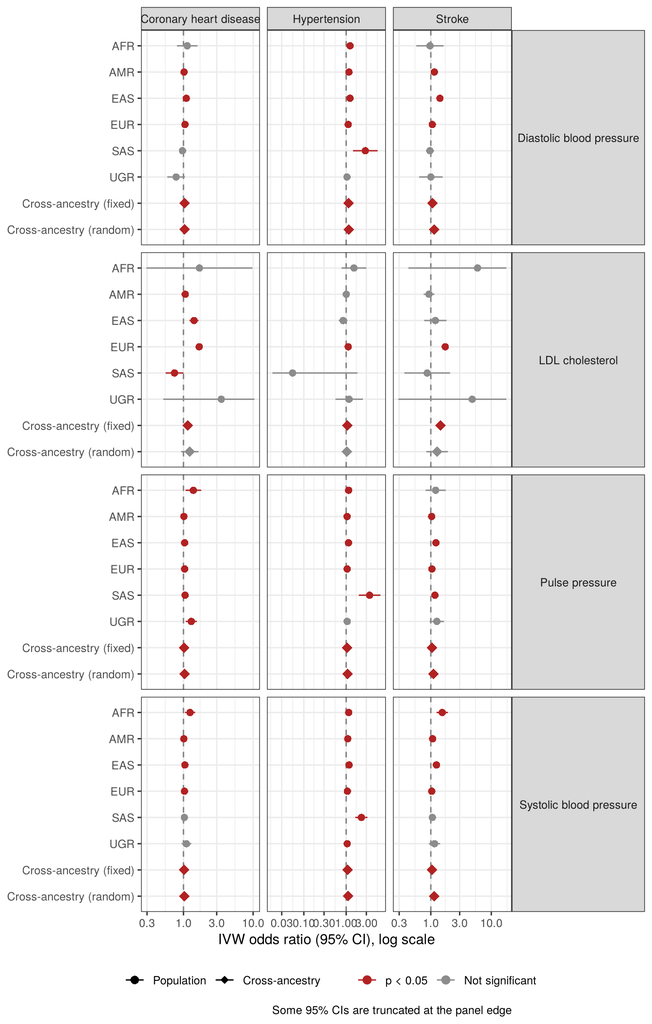

# 4 Results by exposure–outcome pair

## 4.1 Diastolic blood pressure → Coronary heart disease

MR estimates: Diastolic blood pressure → Coronary heart disease

| population | outcome_population | method | nsnp | b | se | pval | OR (95% CI) |
| --- | --- | --- | --- | --- | --- | --- | --- |
| AFR | AFR | Inverse variance weighted | 138 | 0.124 | 0.174 | 4.75e-01 | 1.132 (0.805–1.593) |
| AFR | AFR | MR Egger | 138 | 0.166 | 0.268 | 5.37e-01 | 1.180 (0.698–1.995) |
| AFR | AFR | Weighted median | 138 | 0.170 | 0.297 | 5.68e-01 | 1.185 (0.662–2.122) |
| AFR | AFR | Weighted mode | 138 | 0.244 | 15.889 | 9.88e-01 | 1.276 (0.000–42719868641387.305) |
| AMR | AMR | Inverse variance weighted | 138 | 0.021 | 0.005 | 8.18e-06 | 1.021 (1.012–1.031) |
| AMR | AMR | MR Egger | 138 | 0.021 | 0.011 | 5.59e-02 | 1.021 (1.000–1.043) |
| AMR | AMR | Weighted median | 138 | 0.023 | 0.007 | 5.04e-04 | 1.023 (1.010–1.037) |
| AMR | AMR | Weighted mode | 138 | 0.029 | 0.011 | 9.97e-03 | 1.029 (1.007–1.052) |
| EAS | EAS | Inverse variance weighted | 138 | 0.093 | 0.013 | 8.57e-14 | 1.098 (1.071–1.125) |
| EAS | EAS | MR Egger | 138 | 0.106 | 0.029 | 3.08e-04 | 1.112 (1.051–1.176) |
| EAS | EAS | Weighted median | 138 | 0.091 | 0.019 | 1.39e-06 | 1.095 (1.055–1.136) |
| EAS | EAS | Weighted mode | 138 | 0.093 | 0.104 | 3.70e-01 | 1.098 (0.896–1.345) |
| EUR | EUR | Inverse variance weighted | 136 | 0.051 | 0.006 | 4.73e-20 | 1.053 (1.041–1.064) |
| EUR | EUR | MR Egger | 136 | 0.048 | 0.016 | 3.95e-03 | 1.049 (1.016–1.083) |
| EUR | EUR | Weighted median | 136 | 0.043 | 0.005 | 1.01e-20 | 1.044 (1.035–1.054) |
| EUR | EUR | Weighted mode | 136 | 0.038 | 0.010 | 3.72e-04 | 1.039 (1.018–1.060) |
| SAS | SAS | Inverse variance weighted | 137 | -0.032 | 0.030 | 2.85e-01 | 0.968 (0.912–1.027) |
| SAS | SAS | MR Egger | 137 | -0.048 | 0.048 | 3.22e-01 | 0.954 (0.868–1.047) |
| SAS | SAS | Weighted median | 137 | 0.038 | 0.049 | 4.37e-01 | 1.039 (0.944–1.143) |
| SAS | SAS | Weighted mode | 137 | -0.087 | 8.802 | 9.92e-01 | 0.917 (0.000–28516609.366) |
| UGR | AFR | Inverse variance weighted | 137 | -0.243 | 0.149 | 1.03e-01 | 0.784 (0.585–1.050) |
| UGR | AFR | MR Egger | 137 | -0.043 | 0.239 | 8.56e-01 | 0.958 (0.600–1.529) |
| UGR | AFR | Weighted median | 137 | -0.291 | 0.243 | 2.31e-01 | 0.748 (0.465–1.203) |
| UGR | AFR | Weighted mode | 137 | -0.001 | 17.882 | 1.00e+00 | 0.999 (0.000–1662583556604416.000) |

Cochran’s Q heterogeneity (between SNPs): Diastolic blood pressure → Coronary heart disease

| population | method | Q | Q_df | Q_pval |
| --- | --- | --- | --- | --- |
| AFR | MR Egger | 131.88 | 136 | 5.84e-01 |
| AFR | Inverse variance weighted | 131.92 | 137 | 6.07e-01 |
| AMR | MR Egger | 173.17 | 136 | 1.72e-02 |
| AMR | Inverse variance weighted | 173.17 | 137 | 1.98e-02 |
| EAS | MR Egger | 177.75 | 136 | 9.38e-03 |
| EAS | Inverse variance weighted | 178.07 | 137 | 1.05e-02 |
| EUR | MR Egger | 627.92 | 134 | 6.44e-65 |
| EUR | Inverse variance weighted | 628.12 | 135 | 1.29e-64 |
| SAS | MR Egger | 142.84 | 135 | 3.05e-01 |
| SAS | Inverse variance weighted | 143.02 | 136 | 3.23e-01 |
| UGR | MR Egger | 128.61 | 135 | 6.38e-01 |
| UGR | Inverse variance weighted | 129.76 | 136 | 6.34e-01 |

MR-Egger intercept test: Diastolic blood pressure → Coronary heart disease

| population | egger_intercept | se | pval |
| --- | --- | --- | --- |
| AFR | -0.0254 | 0.1243 | 8.39e-01 |
| AMR | 0.0001 | 0.0033 | 9.79e-01 |
| EAS | -0.0039 | 0.0080 | 6.22e-01 |
| EUR | 0.0009 | 0.0042 | 8.35e-01 |
| SAS | 0.0102 | 0.0247 | 6.82e-01 |
| UGR | -0.1396 | 0.1303 | 2.86e-01 |

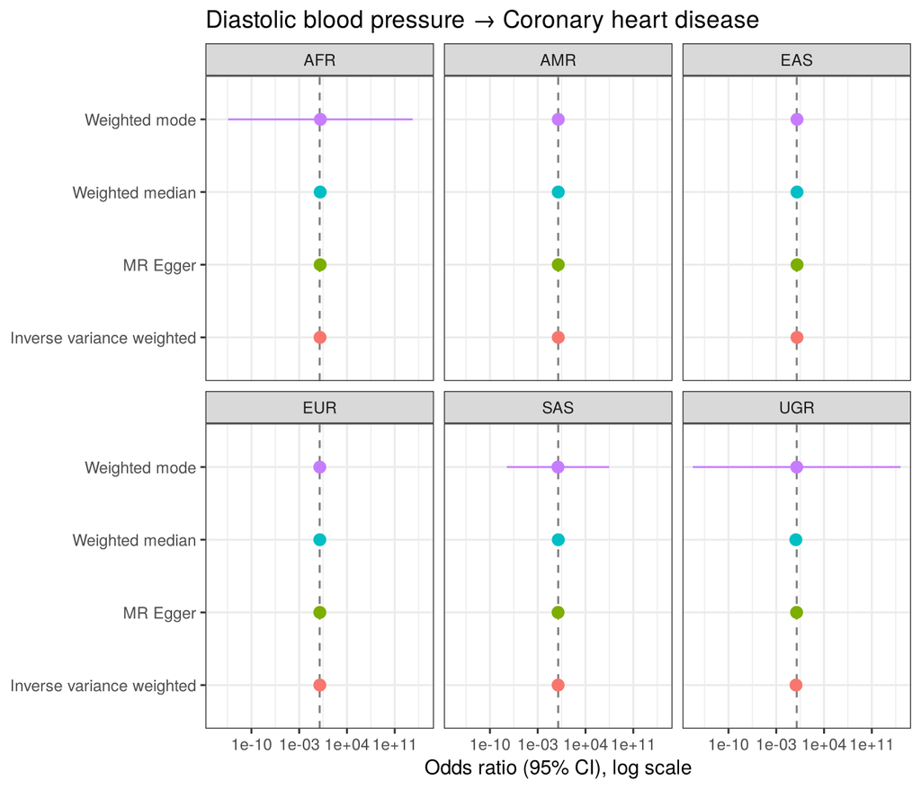

## 4.2 Diastolic blood pressure → Hypertension

MR estimates: Diastolic blood pressure → Hypertension

| population | outcome_population | method | nsnp | b | se | pval | OR (95% CI) |
| --- | --- | --- | --- | --- | --- | --- | --- |
| AFR | AFR | Inverse variance weighted | 138 | 0.215 | 0.057 | 1.46e-04 | 1.240 (1.110–1.386) |
| AFR | AFR | MR Egger | 138 | 0.209 | 0.087 | 1.77e-02 | 1.233 (1.039–1.462) |
| AFR | AFR | Weighted median | 138 | 0.207 | 0.089 | 2.02e-02 | 1.230 (1.033–1.464) |
| AFR | AFR | Weighted mode | 138 | -0.051 | 13.732 | 9.97e-01 | 0.950 (0.000–463800530071.759) |
| AMR | AMR | Inverse variance weighted | 138 | 0.149 | 0.005 | 2.78e-216 | 1.161 (1.150–1.172) |
| AMR | AMR | MR Egger | 138 | 0.129 | 0.011 | 3.62e-23 | 1.137 (1.114–1.161) |
| AMR | AMR | Weighted median | 138 | 0.128 | 0.008 | 1.21e-59 | 1.137 (1.119–1.154) |
| AMR | AMR | Weighted mode | 138 | 0.125 | 0.012 | 2.30e-18 | 1.133 (1.106–1.160) |
| EAS | EAS | Inverse variance weighted | 138 | 0.212 | 0.042 | 4.59e-07 | 1.236 (1.138–1.342) |
| EAS | EAS | MR Egger | 138 | 0.361 | 0.095 | 2.24e-04 | 1.435 (1.191–1.729) |
| EAS | EAS | Weighted median | 138 | 0.426 | 0.033 | 5.44e-38 | 1.532 (1.435–1.634) |
| EAS | EAS | Weighted mode | 138 | 0.517 | 0.084 | 7.84e-09 | 1.677 (1.423–1.978) |
| EUR | EUR | Inverse variance weighted | 136 | 0.114 | 0.005 | 4.29e-114 | 1.120 (1.109–1.131) |
| EUR | EUR | MR Egger | 136 | 0.103 | 0.015 | 9.93e-11 | 1.108 (1.077–1.141) |
| EUR | EUR | Weighted median | 136 | 0.094 | 0.004 | 1.08e-103 | 1.099 (1.089–1.108) |
| EUR | EUR | Weighted mode | 136 | 0.096 | 0.013 | 3.71e-11 | 1.100 (1.072–1.130) |
| SAS | SAS | Inverse variance weighted | 137 | 1.043 | 0.342 | 2.28e-03 | 2.838 (1.452–5.545) |
| SAS | SAS | MR Egger | 137 | 1.582 | 0.538 | 3.86e-03 | 4.866 (1.695–13.971) |
| SAS | SAS | Weighted median | 137 | 1.057 | 0.530 | 4.59e-02 | 2.878 (1.019–8.126) |
| SAS | SAS | Weighted mode | 137 | -0.393 | 132.454 | 9.98e-01 | 0.675 (0.000–37692111900712114709191192104956030581399947160006138197059328829379452622671406550170159059458924813393468588032.000) |
| UGR | AFR | Inverse variance weighted | 137 | 0.044 | 0.049 | 3.76e-01 | 1.045 (0.948–1.150) |
| UGR | AFR | MR Egger | 137 | -0.044 | 0.079 | 5.81e-01 | 0.957 (0.821–1.117) |
| UGR | AFR | Weighted median | 137 | -0.026 | 0.074 | 7.27e-01 | 0.975 (0.843–1.126) |
| UGR | AFR | Weighted mode | 137 | -0.067 | 13.318 | 9.96e-01 | 0.935 (0.000–203058212404.301) |

Cochran’s Q heterogeneity (between SNPs): Diastolic blood pressure → Hypertension

| population | method | Q | Q_df | Q_pval |
| --- | --- | --- | --- | --- |
| AFR | MR Egger | 130.00 | 136 | 6.29e-01 |
| AFR | Inverse variance weighted | 130.01 | 137 | 6.51e-01 |
| AMR | MR Egger | 193.24 | 136 | 9.17e-04 |
| AMR | Inverse variance weighted | 199.87 | 137 | 3.70e-04 |
| EAS | MR Egger | 1172.38 | 136 | 2.35e-164 |
| EAS | Inverse variance weighted | 1198.48 | 137 | 6.53e-169 |
| EUR | MR Egger | 1172.89 | 134 | 2.13e-165 |
| EUR | Inverse variance weighted | 1178.34 | 135 | 5.65e-166 |
| SAS | MR Egger | 153.28 | 135 | 1.34e-01 |
| SAS | Inverse variance weighted | 155.19 | 136 | 1.24e-01 |
| UGR | MR Egger | 138.26 | 135 | 4.06e-01 |
| UGR | Inverse variance weighted | 140.32 | 136 | 3.82e-01 |

MR-Egger intercept test: Diastolic blood pressure → Hypertension

| population | egger_intercept | se | pval |
| --- | --- | --- | --- |
| AFR | 0.0037 | 0.0403 | 9.27e-01 |
| AMR | 0.0072 | 0.0033 | 3.25e-02 |
| EAS | -0.0462 | 0.0266 | 8.41e-02 |
| EUR | 0.0029 | 0.0037 | 4.32e-01 |
| SAS | -0.3598 | 0.2778 | 1.97e-01 |
| UGR | 0.0607 | 0.0428 | 1.59e-01 |

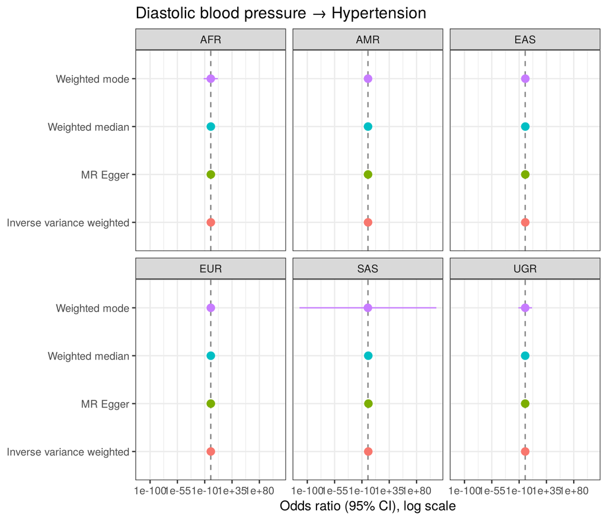

## 4.3 Diastolic blood pressure → Stroke

MR estimates: Diastolic blood pressure → Stroke

| population | outcome_population | method | nsnp | b | se | pval | OR (95% CI) |
| --- | --- | --- | --- | --- | --- | --- | --- |
| AFR | AFR | Inverse variance weighted | 138 | -0.033 | 0.266 | 9.02e-01 | 0.968 (0.575–1.631) |
| AFR | AFR | MR Egger | 138 | -0.014 | 0.411 | 9.73e-01 | 0.986 (0.441–2.206) |
| AFR | AFR | Weighted median | 138 | -0.418 | 0.408 | 3.06e-01 | 0.659 (0.296–1.465) |
| AFR | AFR | Weighted mode | 138 | -0.127 | 8.843 | 9.89e-01 | 0.881 (0.000–29652223.518) |
| AMR | AMR | Inverse variance weighted | 138 | 0.135 | 0.020 | 5.65e-12 | 1.144 (1.101–1.189) |
| AMR | AMR | MR Egger | 138 | 0.138 | 0.045 | 2.44e-03 | 1.148 (1.052–1.253) |
| AMR | AMR | Weighted median | 138 | 0.129 | 0.029 | 8.55e-06 | 1.138 (1.075–1.204) |
| AMR | AMR | Weighted mode | 138 | 0.133 | 0.048 | 6.09e-03 | 1.142 (1.040–1.254) |
| EAS | EAS | Inverse variance weighted | 137 | 0.347 | 0.034 | 8.46e-25 | 1.415 (1.325–1.512) |
| EAS | EAS | MR Egger | 137 | 0.492 | 0.076 | 1.70e-09 | 1.635 (1.409–1.898) |
| EAS | EAS | Weighted median | 137 | 0.372 | 0.049 | 3.71e-14 | 1.450 (1.317–1.597) |
| EAS | EAS | Weighted mode | 137 | 0.496 | 0.182 | 7.35e-03 | 1.642 (1.149–2.346) |
| EUR | EUR | Inverse variance weighted | 136 | 0.056 | 0.006 | 1.48e-21 | 1.058 (1.045–1.070) |
| EUR | EUR | MR Egger | 136 | 0.065 | 0.017 | 2.53e-04 | 1.067 (1.031–1.103) |
| EUR | EUR | Weighted median | 136 | 0.050 | 0.005 | 3.72e-20 | 1.051 (1.040–1.063) |
| EUR | EUR | Weighted mode | 136 | 0.055 | 0.013 | 2.73e-05 | 1.056 (1.030–1.083) |
| SAS | SAS | Inverse variance weighted | 137 | -0.032 | 0.079 | 6.88e-01 | 0.969 (0.830–1.131) |
| SAS | SAS | MR Egger | 137 | -0.166 | 0.124 | 1.83e-01 | 0.847 (0.664–1.080) |
| SAS | SAS | Weighted median | 137 | -0.018 | 0.124 | 8.85e-01 | 0.982 (0.771–1.252) |
| SAS | SAS | Weighted mode | 137 | 0.222 | 24.328 | 9.93e-01 | 1.248 (0.000–637789723267851616256.000) |
| UGR | AFR | Inverse variance weighted | 137 | 0.003 | 0.228 | 9.90e-01 | 1.003 (0.641–1.569) |
| UGR | AFR | MR Egger | 137 | 0.186 | 0.366 | 6.12e-01 | 1.204 (0.588–2.469) |
| UGR | AFR | Weighted median | 137 | -0.056 | 0.368 | 8.79e-01 | 0.946 (0.460–1.944) |
| UGR | AFR | Weighted mode | 137 | -0.465 | 38.073 | 9.90e-01 | 0.628 (0.000–160959896300703261295097984057344.000) |

Cochran’s Q heterogeneity (between SNPs): Diastolic blood pressure → Stroke

| population | method | Q | Q_df | Q_pval |
| --- | --- | --- | --- | --- |
| AFR | MR Egger | 163.44 | 136 | 5.44e-02 |
| AFR | Inverse variance weighted | 163.45 | 137 | 6.12e-02 |
| AMR | MR Egger | 153.08 | 136 | 1.50e-01 |
| AMR | Inverse variance weighted | 153.09 | 137 | 1.65e-01 |
| EAS | MR Egger | 192.57 | 135 | 8.42e-04 |
| EAS | Inverse variance weighted | 198.94 | 136 | 3.53e-04 |
| EUR | MR Egger | 459.65 | 134 | 2.82e-37 |
| EUR | Inverse variance weighted | 460.63 | 135 | 3.70e-37 |
| SAS | MR Egger | 155.19 | 135 | 1.13e-01 |
| SAS | Inverse variance weighted | 157.44 | 136 | 1.01e-01 |
| UGR | MR Egger | 162.96 | 135 | 5.09e-02 |
| UGR | Inverse variance weighted | 163.46 | 136 | 5.43e-02 |

MR-Egger intercept test: Diastolic blood pressure → Stroke

| population | egger_intercept | se | pval |
| --- | --- | --- | --- |
| AFR | -0.0114 | 0.1905 | 9.53e-01 |
| AMR | -0.0013 | 0.0140 | 9.28e-01 |
| EAS | -0.0448 | 0.0212 | 3.65e-02 |
| EUR | -0.0023 | 0.0044 | 5.93e-01 |
| SAS | 0.0897 | 0.0641 | 1.64e-01 |
| UGR | -0.1281 | 0.1998 | 5.23e-01 |

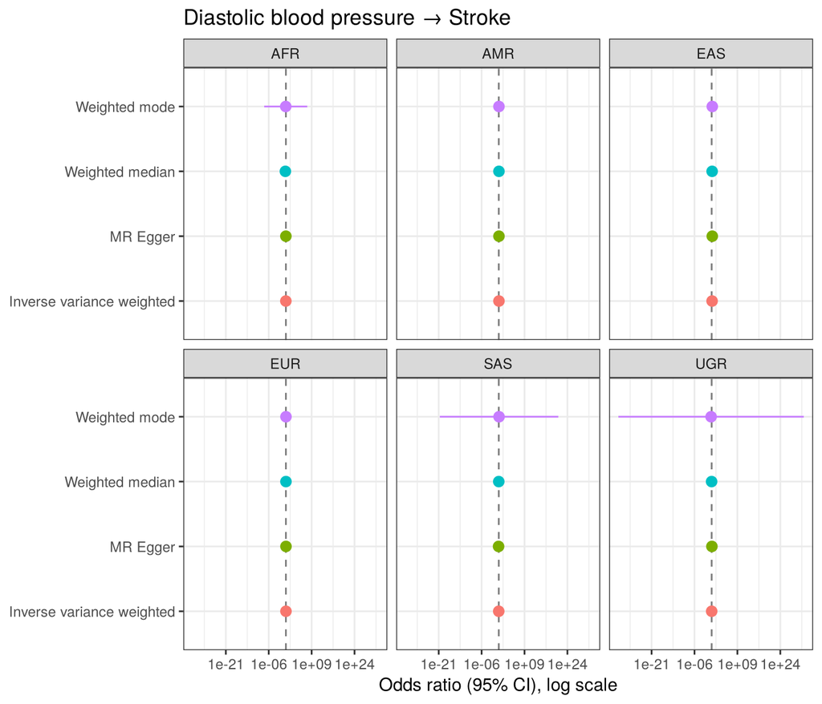

## 4.4 LDL cholesterol → Coronary heart disease

MR estimates: LDL cholesterol → Coronary heart disease

| population | outcome_population | method | nsnp | b | se | pval | OR (95% CI) |
| --- | --- | --- | --- | --- | --- | --- | --- |
| AFR | AFR | Inverse variance weighted | 225 | 0.528 | 0.894 | 5.55e-01 | 1.696 (0.294–9.771) |
| AFR | AFR | MR Egger | 225 | 2.371 | 1.334 | 7.68e-02 | 10.713 (0.784–146.350) |
| AFR | AFR | Weighted median | 225 | 1.193 | 1.388 | 3.90e-01 | 3.296 (0.217–50.074) |
| AFR | AFR | Weighted mode | 225 | 1.949 | 93.101 | 9.83e-01 | 7.024 (0.000–124737716452113200028252965203040537061854495496322918411828336732843579570913280.000) |
| AMR | AMR | Inverse variance weighted | 221 | 0.059 | 0.022 | 6.93e-03 | 1.061 (1.016–1.107) |
| AMR | AMR | MR Egger | 221 | 0.063 | 0.034 | 6.15e-02 | 1.065 (0.997–1.138) |
| AMR | AMR | Weighted median | 221 | 0.071 | 0.035 | 4.66e-02 | 1.073 (1.001–1.150) |
| AMR | AMR | Weighted mode | 221 | 0.065 | 0.413 | 8.76e-01 | 1.067 (0.474–2.399) |
| EAS | EAS | Inverse variance weighted | 225 | 0.349 | 0.076 | 4.75e-06 | 1.418 (1.221–1.646) |
| EAS | EAS | MR Egger | 225 | 0.336 | 0.100 | 9.35e-04 | 1.399 (1.150–1.703) |
| EAS | EAS | Weighted median | 225 | 0.209 | 0.120 | 8.12e-02 | 1.233 (0.974–1.560) |
| EAS | EAS | Weighted mode | 225 | -0.878 | 778.889 | 9.99e-01 | 0.415 (0.000– Inf) |
| EUR | EUR | Inverse variance weighted | 222 | 0.520 | 0.048 | 9.92e-28 | 1.682 (1.532–1.847) |
| EUR | EUR | MR Egger | 222 | 0.475 | 0.070 | 9.13e-11 | 1.609 (1.403–1.845) |
| EUR | EUR | Weighted median | 222 | 0.466 | 0.043 | 3.52e-27 | 1.594 (1.465–1.735) |
| EUR | EUR | Weighted mode | 222 | 0.366 | 0.069 | 2.49e-07 | 1.441 (1.260–1.649) |
| SAS | SAS | Inverse variance weighted | 221 | -0.296 | 0.150 | 4.81e-02 | 0.744 (0.554–0.997) |
| SAS | SAS | MR Egger | 221 | -0.066 | 0.236 | 7.80e-01 | 0.936 (0.590–1.486) |
| SAS | SAS | Weighted median | 221 | -0.035 | 0.251 | 8.88e-01 | 0.965 (0.590–1.578) |
| SAS | SAS | Weighted mode | 221 | -0.256 | 10.158 | 9.80e-01 | 0.774 (0.000–342979142.336) |
| UGR | AFR | Inverse variance weighted | 223 | 1.250 | 0.978 | 2.01e-01 | 3.489 (0.513–23.724) |
| UGR | AFR | MR Egger | 223 | 1.566 | 1.422 | 2.72e-01 | 4.788 (0.295–77.660) |
| UGR | AFR | Weighted median | 223 | 0.945 | 1.678 | 5.73e-01 | 2.574 (0.096–69.014) |
| UGR | AFR | Weighted mode | 223 | 2.954 | 499.157 | 9.95e-01 | 19.177 (0.000– Inf) |

Cochran’s Q heterogeneity (between SNPs): LDL cholesterol → Coronary heart disease

| population | method | Q | Q_df | Q_pval |
| --- | --- | --- | --- | --- |
| AFR | MR Egger | 241.18 | 223 | 1.92e-01 |
| AFR | Inverse variance weighted | 244.89 | 224 | 1.61e-01 |
| AMR | MR Egger | 245.72 | 219 | 1.04e-01 |
| AMR | Inverse variance weighted | 245.75 | 220 | 1.12e-01 |
| EAS | MR Egger | 272.37 | 223 | 1.34e-02 |
| EAS | Inverse variance weighted | 272.42 | 224 | 1.49e-02 |
| EUR | MR Egger | 1487.62 | 220 | 7.34e-187 |
| EUR | Inverse variance weighted | 1492.79 | 221 | 2.11e-187 |
| SAS | MR Egger | 216.36 | 219 | 5.38e-01 |
| SAS | Inverse variance weighted | 217.96 | 220 | 5.26e-01 |
| UGR | MR Egger | 241.53 | 221 | 1.64e-01 |
| UGR | Inverse variance weighted | 241.64 | 222 | 1.74e-01 |

MR-Egger intercept test: LDL cholesterol → Coronary heart disease

| population | egger_intercept | se | pval |
| --- | --- | --- | --- |
| AFR | -0.1773 | 0.0957 | 6.52e-02 |
| AMR | -0.0003 | 0.0017 | 8.72e-01 |
| EAS | 0.0008 | 0.0038 | 8.41e-01 |
| EUR | 0.0018 | 0.0020 | 3.83e-01 |
| SAS | -0.0252 | 0.0199 | 2.07e-01 |
| UGR | -0.0288 | 0.0936 | 7.59e-01 |

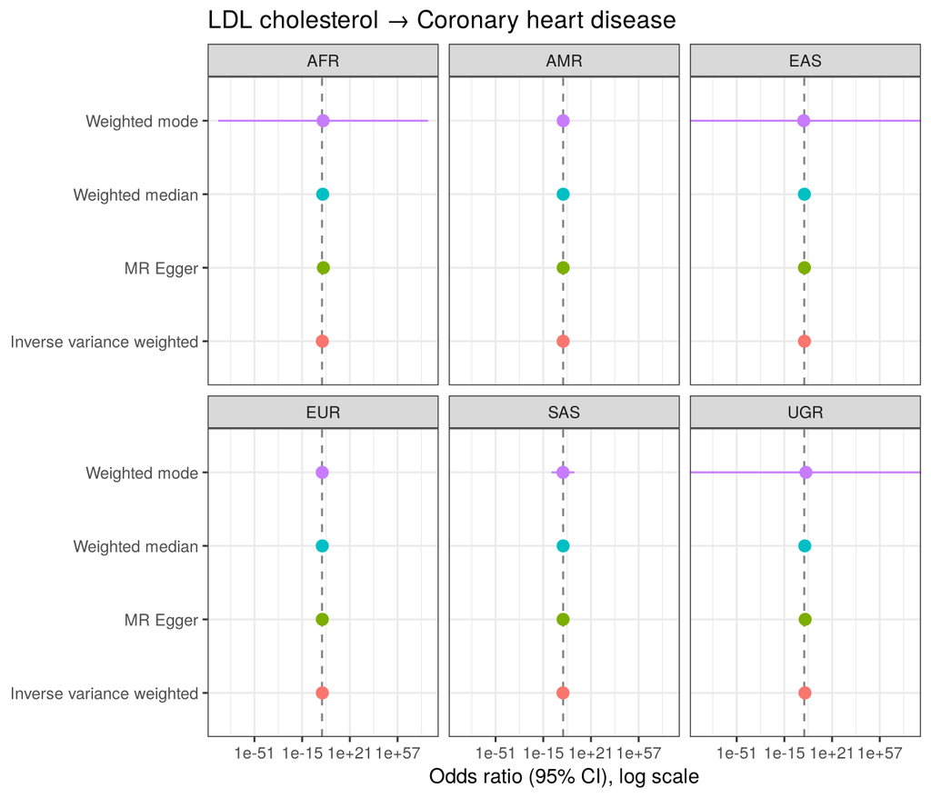

## 4.5 LDL cholesterol → Hypertension

MR estimates: LDL cholesterol → Hypertension

| population | outcome_population | method | nsnp | b | se | pval | OR (95% CI) |
| --- | --- | --- | --- | --- | --- | --- | --- |
| AFR | AFR | Inverse variance weighted | 169 | 0.423 | 0.345 | 2.20e-01 | 1.527 (0.776–3.003) |
| AFR | AFR | MR Egger | 169 | 0.582 | 0.520 | 2.64e-01 | 1.790 (0.646–4.955) |
| AFR | AFR | Weighted median | 169 | 0.850 | 0.516 | 9.92e-02 | 2.341 (0.852–6.433) |
| AFR | AFR | Weighted mode | 169 | 0.376 | 46.044 | 9.93e-01 | 1.457 (0.000–2273480102361922060045060648154678951936.000) |
| AMR | AMR | Inverse variance weighted | 165 | 0.006 | 0.028 | 8.21e-01 | 1.006 (0.952–1.063) |
| AMR | AMR | MR Egger | 165 | -0.022 | 0.042 | 6.03e-01 | 0.978 (0.901–1.062) |
| AMR | AMR | Weighted median | 165 | -0.017 | 0.043 | 6.90e-01 | 0.983 (0.904–1.069) |
| AMR | AMR | Weighted mode | 165 | -0.025 | 0.157 | 8.71e-01 | 0.975 (0.717–1.326) |
| EAS | EAS | Inverse variance weighted | 168 | -0.164 | 0.120 | 1.73e-01 | 0.849 (0.670–1.074) |
| EAS | EAS | MR Egger | 168 | -0.214 | 0.152 | 1.62e-01 | 0.807 (0.599–1.088) |
| EAS | EAS | Weighted median | 168 | -0.069 | 0.157 | 6.60e-01 | 0.933 (0.686–1.270) |
| EAS | EAS | Weighted mode | 168 | -0.571 | 11.533 | 9.61e-01 | 0.565 (0.000–3709737098.477) |
| EUR | EUR | Inverse variance weighted | 166 | 0.111 | 0.024 | 4.55e-06 | 1.117 (1.066–1.171) |
| EUR | EUR | MR Egger | 166 | 0.109 | 0.036 | 2.84e-03 | 1.116 (1.039–1.197) |
| EUR | EUR | Weighted median | 166 | 0.087 | 0.024 | 3.56e-04 | 1.091 (1.040–1.145) |
| EUR | EUR | Weighted mode | 166 | 0.091 | 0.040 | 2.47e-02 | 1.095 (1.012–1.184) |
| SAS | SAS | Inverse variance weighted | 165 | -2.915 | 1.802 | 1.06e-01 | 0.054 (0.002–1.853) |
| SAS | SAS | MR Egger | 165 | -3.966 | 2.846 | 1.65e-01 | 0.019 (0.000–5.018) |
| SAS | SAS | Weighted median | 165 | -1.029 | 3.215 | 7.49e-01 | 0.357 (0.001–194.702) |
| SAS | SAS | Weighted mode | 165 | -4.225 | 94.229 | 9.64e-01 | 0.015 (0.000–2369205502405709348716297148821196318599736740890230109560396640378187541381120.000) |
| UGR | AFR | Inverse variance weighted | 167 | 0.162 | 0.381 | 6.70e-01 | 1.176 (0.558–2.480) |
| UGR | AFR | MR Egger | 167 | 0.184 | 0.544 | 7.36e-01 | 1.202 (0.414–3.489) |
| UGR | AFR | Weighted median | 167 | 0.487 | 0.618 | 4.31e-01 | 1.627 (0.484–5.465) |
| UGR | AFR | Weighted mode | 167 | -1.863 | 168.640 | 9.91e-01 | 0.155 (0.000–55017568954630075203820373766041401990034869668705845174428256684503826408305299781179893425222165473976935348196326027238222340038537062121472.000) |

Cochran’s Q heterogeneity (between SNPs): LDL cholesterol → Hypertension

| population | method | Q | Q_df | Q_pval |
| --- | --- | --- | --- | --- |
| AFR | MR Egger | 206.21 | 167 | 2.10e-02 |
| AFR | Inverse variance weighted | 206.42 | 168 | 2.33e-02 |
| AMR | MR Egger | 287.04 | 163 | 6.96e-09 |
| AMR | Inverse variance weighted | 288.48 | 164 | 6.76e-09 |
| EAS | MR Egger | 219.72 | 166 | 3.31e-03 |
| EAS | Inverse variance weighted | 220.11 | 167 | 3.68e-03 |
| EUR | MR Egger | 584.06 | 164 | 1.78e-48 |
| EUR | Inverse variance weighted | 584.07 | 165 | 3.35e-48 |
| SAS | MR Egger | 164.27 | 163 | 4.57e-01 |
| SAS | Inverse variance weighted | 164.50 | 164 | 4.74e-01 |
| UGR | MR Egger | 207.61 | 165 | 1.37e-02 |
| UGR | Inverse variance weighted | 207.61 | 166 | 1.57e-02 |

MR-Egger intercept test: LDL cholesterol → Hypertension

| population | egger_intercept | se | pval |
| --- | --- | --- | --- |
| AFR | -0.0156 | 0.0381 | 6.83e-01 |
| AMR | 0.0020 | 0.0022 | 3.66e-01 |
| EAS | 0.0030 | 0.0056 | 5.91e-01 |
| EUR | 0.0001 | 0.0011 | 9.54e-01 |
| SAS | 0.1169 | 0.2446 | 6.33e-01 |
| UGR | -0.0021 | 0.0368 | 9.56e-01 |

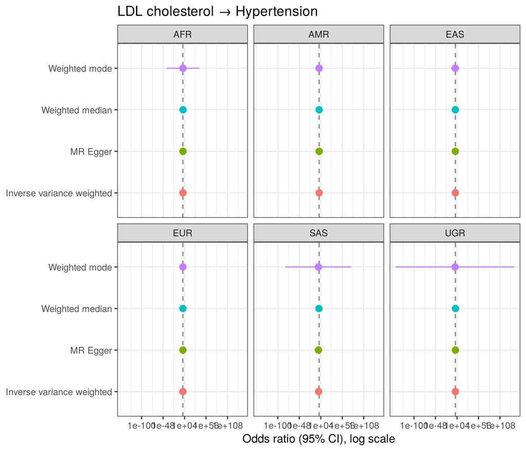

## 4.6 LDL cholesterol → Stroke

MR estimates: LDL cholesterol → Stroke

| population | outcome_population | method | nsnp | b | se | pval | OR (95% CI) |
| --- | --- | --- | --- | --- | --- | --- | --- |
| AFR | AFR | Inverse variance weighted | 169 | 1.778 | 1.343 | 1.86e-01 | 5.919 (0.426–82.325) |
| AFR | AFR | MR Egger | 169 | 4.286 | 2.017 | 3.51e-02 | 72.674 (1.394–3788.531) |
| AFR | AFR | Weighted median | 169 | 3.306 | 2.132 | 1.21e-01 | 27.289 (0.418–1782.756) |
| AFR | AFR | Weighted mode | 169 | 2.848 | 66.689 | 9.66e-01 | 17.258 (0.000–10091942135073237248980343803726738616274859400717997703168.000) |
| AMR | AMR | Inverse variance weighted | 165 | -0.068 | 0.105 | 5.18e-01 | 0.934 (0.761–1.148) |
| AMR | AMR | MR Egger | 165 | -0.293 | 0.155 | 6.10e-02 | 0.746 (0.550–1.012) |
| AMR | AMR | Weighted median | 165 | -0.083 | 0.161 | 6.04e-01 | 0.920 (0.672–1.260) |
| AMR | AMR | Weighted mode | 165 | -0.154 | 1.933 | 9.36e-01 | 0.857 (0.019–37.880) |
| EAS | EAS | Inverse variance weighted | 168 | 0.173 | 0.217 | 4.26e-01 | 1.189 (0.777–1.820) |
| EAS | EAS | MR Egger | 168 | 0.089 | 0.274 | 7.47e-01 | 1.093 (0.638–1.871) |
| EAS | EAS | Weighted median | 168 | 0.049 | 0.297 | 8.68e-01 | 1.051 (0.587–1.879) |
| EAS | EAS | Weighted mode | 168 | -0.217 | 8.690 | 9.80e-01 | 0.805 (0.000–20090116.306) |
| EUR | EUR | Inverse variance weighted | 166 | 0.549 | 0.062 | 1.05e-18 | 1.732 (1.533–1.957) |
| EUR | EUR | MR Egger | 166 | 0.585 | 0.093 | 2.55e-09 | 1.795 (1.496–2.153) |
| EUR | EUR | Weighted median | 166 | 0.490 | 0.050 | 5.62e-23 | 1.633 (1.481–1.800) |
| EUR | EUR | Weighted mode | 166 | 0.478 | 0.065 | 9.80e-12 | 1.612 (1.419–1.832) |
| SAS | SAS | Inverse variance weighted | 165 | -0.137 | 0.443 | 7.57e-01 | 0.872 (0.366–2.079) |
| SAS | SAS | MR Egger | 165 | -0.376 | 0.700 | 5.92e-01 | 0.687 (0.174–2.709) |
| SAS | SAS | Weighted median | 165 | 0.015 | 0.680 | 9.83e-01 | 1.015 (0.268–3.847) |
| SAS | SAS | Weighted mode | 165 | 0.736 | 26.916 | 9.78e-01 | 2.088 (0.000–170328137887606588309504.000) |
| UGR | AFR | Inverse variance weighted | 167 | 1.575 | 1.466 | 2.83e-01 | 4.831 (0.273–85.561) |
| UGR | AFR | MR Egger | 167 | 3.564 | 2.090 | 9.00e-02 | 35.305 (0.587–2122.805) |
| UGR | AFR | Weighted median | 167 | 4.056 | 2.425 | 9.45e-02 | 57.719 (0.498–6692.183) |
| UGR | AFR | Weighted mode | 167 | -1.111 | 161.494 | 9.95e-01 | 0.329 (0.000–96404135698934159881548053790211310053855780267581159611573551345115556651367527519593243630548548597619155764457887901491524380861136896.000) |

Cochran’s Q heterogeneity (between SNPs): LDL cholesterol → Stroke

| population | method | Q | Q_df | Q_pval |
| --- | --- | --- | --- | --- |
| AFR | MR Egger | 132.98 | 167 | 9.75e-01 |
| AFR | Inverse variance weighted | 135.75 | 168 | 9.68e-01 |
| AMR | MR Egger | 170.51 | 163 | 3.28e-01 |
| AMR | Inverse variance weighted | 174.49 | 164 | 2.73e-01 |
| EAS | MR Egger | 191.51 | 166 | 8.53e-02 |
| EAS | Inverse variance weighted | 191.81 | 167 | 9.15e-02 |
| EUR | MR Egger | 1099.84 | 164 | 2.78e-138 |
| EUR | Inverse variance weighted | 1101.62 | 165 | 3.37e-138 |
| SAS | MR Egger | 189.13 | 163 | 7.89e-02 |
| SAS | Inverse variance weighted | 189.36 | 164 | 8.53e-02 |
| UGR | MR Egger | 133.93 | 165 | 9.64e-01 |
| UGR | Inverse variance weighted | 135.71 | 166 | 9.59e-01 |

MR-Egger intercept test: LDL cholesterol → Stroke

| population | egger_intercept | se | pval |
| --- | --- | --- | --- |
| AFR | -0.2464 | 0.1479 | 9.75e-02 |
| AMR | 0.0160 | 0.0082 | 5.28e-02 |
| EAS | 0.0051 | 0.0101 | 6.15e-01 |
| EUR | -0.0015 | 0.0028 | 6.07e-01 |
| SAS | 0.0266 | 0.0602 | 6.60e-01 |
| UGR | -0.1892 | 0.1416 | 1.84e-01 |

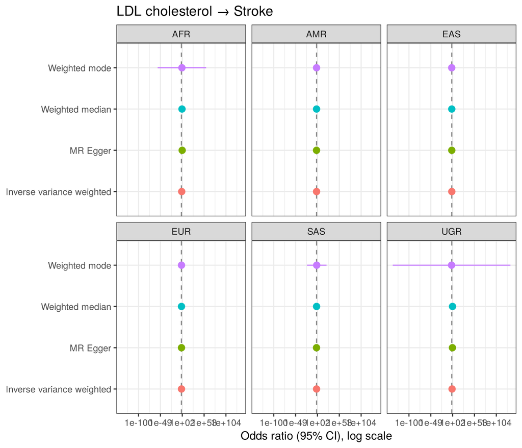

## 4.7 Pulse pressure → Coronary heart disease

MR estimates: Pulse pressure → Coronary heart disease

| population | outcome_population | method | nsnp | b | se | pval | OR (95% CI) |
| --- | --- | --- | --- | --- | --- | --- | --- |
| AFR | AFR | Inverse variance weighted | 187 | 0.327 | 0.132 | 1.31e-02 | 1.386 (1.071–1.794) |
| AFR | AFR | MR Egger | 187 | 0.242 | 0.216 | 2.64e-01 | 1.273 (0.834–1.943) |
| AFR | AFR | Weighted median | 187 | 0.202 | 0.199 | 3.10e-01 | 1.224 (0.829–1.807) |
| AFR | AFR | Weighted mode | 187 | -15.951 | 3896.659 | 9.97e-01 | 0.000 (0.000– Inf) |
| AMR | AMR | Inverse variance weighted | 183 | 0.014 | 0.003 | 4.45e-06 | 1.014 (1.008–1.020) |
| AMR | AMR | MR Egger | 183 | 0.009 | 0.005 | 9.48e-02 | 1.009 (0.998–1.020) |
| AMR | AMR | Weighted median | 183 | 0.008 | 0.005 | 8.30e-02 | 1.008 (0.999–1.018) |
| AMR | AMR | Weighted mode | 183 | 0.003 | 0.051 | 9.51e-01 | 1.003 (0.907–1.110) |
| EAS | EAS | Inverse variance weighted | 186 | 0.040 | 0.008 | 3.23e-07 | 1.041 (1.025–1.057) |
| EAS | EAS | MR Egger | 186 | 0.065 | 0.017 | 2.04e-04 | 1.068 (1.032–1.104) |
| EAS | EAS | Weighted median | 186 | 0.039 | 0.012 | 1.54e-03 | 1.040 (1.015–1.065) |
| EAS | EAS | Weighted mode | 186 | -0.091 | 14.259 | 9.95e-01 | 0.913 (0.000–1252571406265.377) |
| EUR | EUR | Inverse variance weighted | 183 | 0.041 | 0.005 | 2.90e-17 | 1.042 (1.032–1.052) |
| EUR | EUR | MR Egger | 183 | 0.018 | 0.013 | 1.67e-01 | 1.018 (0.992–1.045) |
| EUR | EUR | Weighted median | 183 | 0.036 | 0.004 | 2.73e-20 | 1.037 (1.029–1.045) |
| EUR | EUR | Weighted mode | 183 | 0.039 | 0.009 | 9.17e-06 | 1.040 (1.023–1.058) |
| SAS | SAS | Inverse variance weighted | 182 | 0.055 | 0.027 | 4.52e-02 | 1.056 (1.001–1.115) |
| SAS | SAS | MR Egger | 182 | 0.046 | 0.046 | 3.21e-01 | 1.047 (0.956–1.146) |
| SAS | SAS | Weighted median | 182 | 0.079 | 0.042 | 5.68e-02 | 1.083 (0.998–1.175) |
| SAS | SAS | Weighted mode | 182 | 0.100 | 0.535 | 8.51e-01 | 1.106 (0.387–3.156) |
| UGR | AFR | Inverse variance weighted | 187 | 0.259 | 0.094 | 5.89e-03 | 1.295 (1.077–1.557) |
| UGR | AFR | MR Egger | 187 | 0.179 | 0.153 | 2.45e-01 | 1.196 (0.885–1.614) |
| UGR | AFR | Weighted median | 187 | -0.066 | 0.150 | 6.61e-01 | 0.936 (0.698–1.257) |
| UGR | AFR | Weighted mode | 187 | -0.260 | 55.916 | 9.96e-01 | 0.771 (0.000–304418344622436291293387879941377096323143041024.000) |

Cochran’s Q heterogeneity (between SNPs): Pulse pressure → Coronary heart disease

| population | method | Q | Q_df | Q_pval |
| --- | --- | --- | --- | --- |
| AFR | MR Egger | 213.32 | 185 | 7.53e-02 |
| AFR | Inverse variance weighted | 213.61 | 186 | 8.07e-02 |
| AMR | MR Egger | 194.34 | 181 | 2.36e-01 |
| AMR | Inverse variance weighted | 195.47 | 182 | 2.34e-01 |
| EAS | MR Egger | 213.18 | 184 | 6.92e-02 |
| EAS | Inverse variance weighted | 216.26 | 185 | 5.75e-02 |
| EUR | MR Egger | 1130.66 | 181 | 4.91e-137 |
| EUR | Inverse variance weighted | 1152.70 | 182 | 1.14e-140 |
| SAS | MR Egger | 198.46 | 180 | 1.64e-01 |
| SAS | Inverse variance weighted | 198.53 | 181 | 1.77e-01 |
| UGR | MR Egger | 211.54 | 185 | 8.80e-02 |
| UGR | Inverse variance weighted | 212.04 | 186 | 9.24e-02 |

MR-Egger intercept test: Pulse pressure → Coronary heart disease

| population | egger_intercept | se | pval |
| --- | --- | --- | --- |
| AFR | 0.0588 | 0.1180 | 6.19e-01 |
| AMR | 0.0022 | 0.0021 | 3.06e-01 |
| EAS | -0.0100 | 0.0062 | 1.05e-01 |
| EUR | 0.0071 | 0.0038 | 6.19e-02 |
| SAS | 0.0057 | 0.0231 | 8.06e-01 |
| UGR | 0.0774 | 0.1170 | 5.09e-01 |

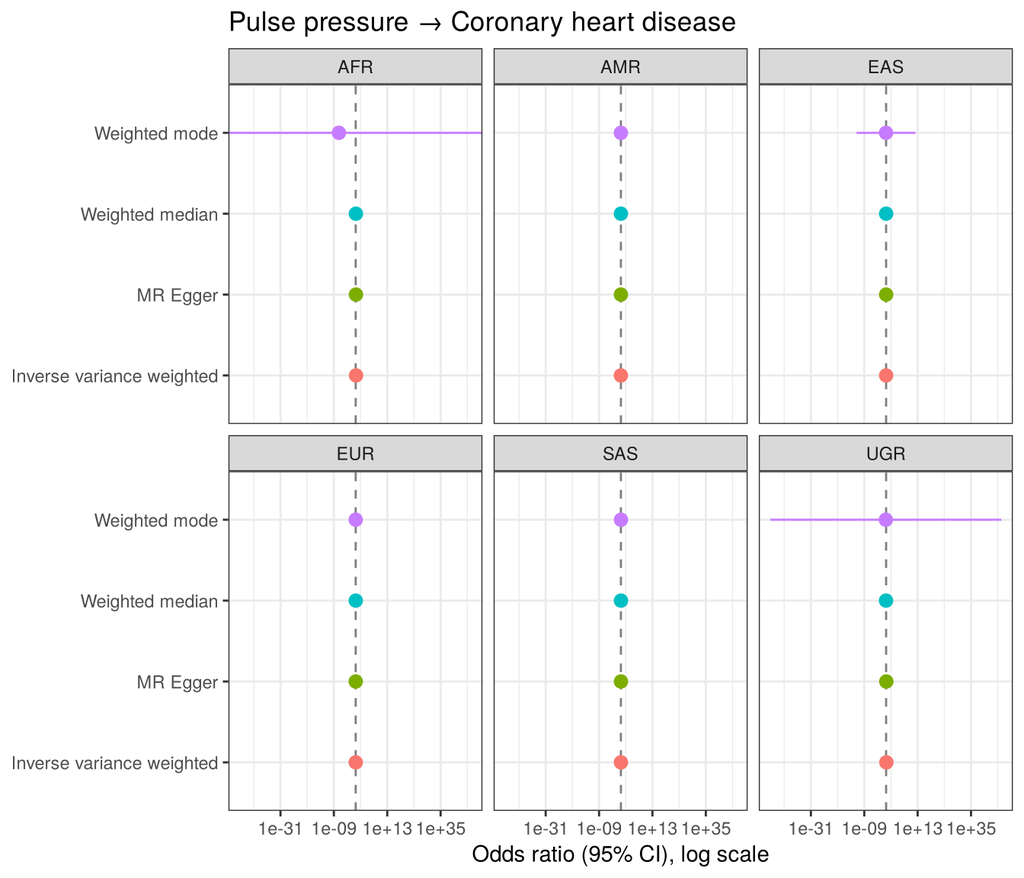

## 4.8 Pulse pressure → Hypertension

MR estimates: Pulse pressure → Hypertension

| population | outcome_population | method | nsnp | b | se | pval | OR (95% CI) |
| --- | --- | --- | --- | --- | --- | --- | --- |
| AFR | AFR | Inverse variance weighted | 187 | 0.135 | 0.040 | 7.41e-04 | 1.144 (1.058–1.237) |
| AFR | AFR | MR Egger | 187 | 0.101 | 0.065 | 1.23e-01 | 1.107 (0.973–1.258) |
| AFR | AFR | Weighted median | 187 | 0.090 | 0.062 | 1.48e-01 | 1.094 (0.969–1.235) |
| AFR | AFR | Weighted mode | 187 | 3.917 | 934.578 | 9.97e-01 | 50.229 (0.000– Inf) |
| AMR | AMR | Inverse variance weighted | 183 | 0.052 | 0.005 | 1.74e-21 | 1.053 (1.042–1.065) |
| AMR | AMR | MR Egger | 183 | 0.042 | 0.010 | 3.87e-05 | 1.042 (1.023–1.063) |
| AMR | AMR | Weighted median | 183 | 0.015 | 0.006 | 7.39e-03 | 1.016 (1.004–1.027) |
| AMR | AMR | Weighted mode | 183 | 0.011 | 0.052 | 8.32e-01 | 1.011 (0.913–1.120) |
| EAS | EAS | Inverse variance weighted | 186 | 0.125 | 0.024 | 1.82e-07 | 1.133 (1.081–1.187) |
| EAS | EAS | MR Egger | 186 | 0.241 | 0.052 | 5.91e-06 | 1.273 (1.150–1.409) |
| EAS | EAS | Weighted median | 186 | 0.166 | 0.022 | 1.56e-13 | 1.180 (1.129–1.233) |
| EAS | EAS | Weighted mode | 186 | 0.258 | 2.812 | 9.27e-01 | 1.295 (0.005–320.405) |
| EUR | EUR | Inverse variance weighted | 183 | 0.056 | 0.005 | 1.11e-32 | 1.058 (1.048–1.067) |
| EUR | EUR | MR Egger | 183 | 0.008 | 0.012 | 5.12e-01 | 1.008 (0.984–1.033) |
| EUR | EUR | Weighted median | 183 | 0.029 | 0.003 | 1.48e-21 | 1.030 (1.023–1.036) |
| EUR | EUR | Weighted mode | 183 | 0.019 | 0.004 | 1.23e-07 | 1.020 (1.013–1.027) |
| SAS | SAS | Inverse variance weighted | 182 | 1.277 | 0.300 | 2.12e-05 | 3.586 (1.990–6.460) |
| SAS | SAS | MR Egger | 182 | 0.906 | 0.504 | 7.38e-02 | 2.474 (0.922–6.642) |
| SAS | SAS | Weighted median | 182 | 1.242 | 0.460 | 6.94e-03 | 3.462 (1.405–8.527) |
| SAS | SAS | Weighted mode | 182 | 1.077 | 6.677 | 8.72e-01 | 2.936 (0.000–1416803.338) |
| UGR | AFR | Inverse variance weighted | 187 | 0.056 | 0.029 | 5.07e-02 | 1.057 (1.000–1.118) |
| UGR | AFR | MR Egger | 187 | 0.024 | 0.047 | 6.07e-01 | 1.024 (0.935–1.123) |
| UGR | AFR | Weighted median | 187 | -0.008 | 0.044 | 8.64e-01 | 0.992 (0.910–1.082) |
| UGR | AFR | Weighted mode | 187 | 0.113 | 13.042 | 9.93e-01 | 1.119 (0.000–141318342695.155) |

Cochran’s Q heterogeneity (between SNPs): Pulse pressure → Hypertension

| population | method | Q | Q_df | Q_pval |
| --- | --- | --- | --- | --- |
| AFR | MR Egger | 157.96 | 185 | 9.26e-01 |
| AFR | Inverse variance weighted | 158.37 | 186 | 9.30e-01 |
| AMR | MR Egger | 744.37 | 181 | 2.35e-69 |
| AMR | Inverse variance weighted | 751.01 | 182 | 3.83e-70 |
| EAS | MR Egger | 1136.20 | 184 | 7.48e-137 |
| EAS | Inverse variance weighted | 1175.79 | 185 | 1.08e-143 |
| EUR | MR Egger | 2268.69 | 181 | 0.00e+00 |
| EUR | Inverse variance weighted | 2491.88 | 182 | 0.00e+00 |
| SAS | MR Egger | 202.53 | 180 | 1.20e-01 |
| SAS | Inverse variance weighted | 203.48 | 181 | 1.21e-01 |
| UGR | MR Egger | 165.20 | 185 | 8.49e-01 |
| UGR | Inverse variance weighted | 165.94 | 186 | 8.52e-01 |

MR-Egger intercept test: Pulse pressure → Hypertension

| population | egger_intercept | se | pval |
| --- | --- | --- | --- |
| AFR | 0.0229 | 0.0357 | 5.22e-01 |
| AMR | 0.0049 | 0.0038 | 2.05e-01 |
| EAS | -0.0467 | 0.0185 | 1.22e-02 |
| EUR | 0.0147 | 0.0035 | 3.86e-05 |
| SAS | 0.2320 | 0.2529 | 3.60e-01 |
| UGR | 0.0306 | 0.0356 | 3.90e-01 |

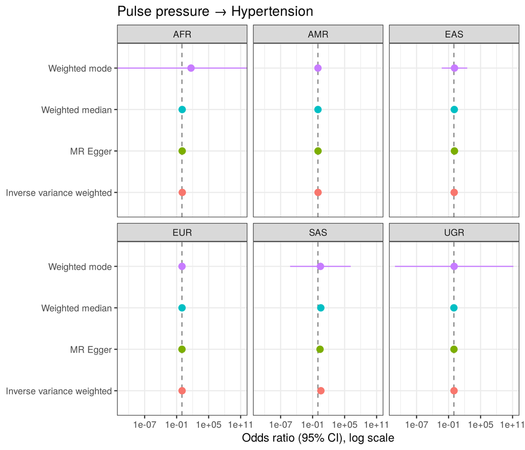

## 4.9 Pulse pressure → Stroke

MR estimates: Pulse pressure → Stroke

| population | outcome_population | method | nsnp | b | se | pval | OR (95% CI) |
| --- | --- | --- | --- | --- | --- | --- | --- |
| AFR | AFR | Inverse variance weighted | 187 | 0.184 | 0.196 | 3.48e-01 | 1.202 (0.819–1.766) |
| AFR | AFR | MR Egger | 187 | 0.135 | 0.322 | 6.76e-01 | 1.144 (0.608–2.152) |
| AFR | AFR | Weighted median | 187 | 0.079 | 0.277 | 7.76e-01 | 1.082 (0.628–1.863) |
| AFR | AFR | Weighted mode | 187 | 52.967 | 4098.815 | 9.90e-01 | 100790469775608804016128.000 (0.000– Inf) |
| AMR | AMR | Inverse variance weighted | 183 | 0.034 | 0.014 | 1.28e-02 | 1.034 (1.007–1.062) |
| AMR | AMR | MR Egger | 183 | 0.046 | 0.025 | 6.33e-02 | 1.047 (0.998–1.099) |
| AMR | AMR | Weighted median | 183 | 0.005 | 0.020 | 8.13e-01 | 1.005 (0.966–1.045) |
| AMR | AMR | Weighted mode | 183 | 0.024 | 0.103 | 8.20e-01 | 1.024 (0.836–1.254) |
| EAS | EAS | Inverse variance weighted | 182 | 0.196 | 0.024 | 4.11e-16 | 1.216 (1.160–1.275) |
| EAS | EAS | MR Egger | 182 | 0.303 | 0.052 | 2.54e-08 | 1.353 (1.222–1.498) |
| EAS | EAS | Weighted median | 182 | 0.161 | 0.033 | 8.17e-07 | 1.175 (1.102–1.252) |
| EAS | EAS | Weighted mode | 182 | 0.049 | 13.076 | 9.97e-01 | 1.050 (0.000–141695246933.017) |
| EUR | EUR | Inverse variance weighted | 183 | 0.043 | 0.006 | 5.77e-15 | 1.044 (1.033–1.056) |
| EUR | EUR | MR Egger | 183 | 0.022 | 0.015 | 1.50e-01 | 1.022 (0.992–1.053) |
| EUR | EUR | Weighted median | 183 | 0.036 | 0.005 | 1.37e-14 | 1.037 (1.027–1.046) |
| EUR | EUR | Weighted mode | 183 | 0.026 | 0.010 | 1.14e-02 | 1.027 (1.006–1.047) |
| SAS | SAS | Inverse variance weighted | 182 | 0.157 | 0.072 | 2.79e-02 | 1.170 (1.017–1.347) |
| SAS | SAS | MR Egger | 182 | 0.125 | 0.120 | 3.00e-01 | 1.133 (0.895–1.435) |
| SAS | SAS | Weighted median | 182 | 0.294 | 0.102 | 3.95e-03 | 1.342 (1.099–1.639) |
| SAS | SAS | Weighted mode | 182 | 0.289 | 1.170 | 8.05e-01 | 1.335 (0.135–13.227) |
| UGR | AFR | Inverse variance weighted | 187 | 0.229 | 0.140 | 1.02e-01 | 1.257 (0.956–1.654) |
| UGR | AFR | MR Egger | 187 | -0.035 | 0.228 | 8.76e-01 | 0.965 (0.618–1.508) |
| UGR | AFR | Weighted median | 187 | -0.053 | 0.200 | 7.92e-01 | 0.949 (0.641–1.404) |
| UGR | AFR | Weighted mode | 187 | 0.052 | 221.255 | 1.00e+00 | 1.054 (0.000–2286507953052726510884007878067855606287258198798090204277372123221905843881445542477491808893006797817684014218558983570077389858154682129955862381304873734365431563835222893603279696035… |

Cochran’s Q heterogeneity (between SNPs): Pulse pressure → Stroke

| population | method | Q | Q_df | Q_pval |
| --- | --- | --- | --- | --- |
| AFR | MR Egger | 242.66 | 185 | 2.83e-03 |
| AFR | Inverse variance weighted | 242.71 | 186 | 3.27e-03 |
| AMR | MR Egger | 206.35 | 181 | 9.52e-02 |
| AMR | Inverse variance weighted | 206.76 | 182 | 1.01e-01 |
| EAS | MR Egger | 292.11 | 180 | 2.46e-07 |
| EAS | Inverse variance weighted | 300.83 | 181 | 5.39e-08 |
| EUR | MR Egger | 975.69 | 181 | 4.23e-109 |
| EUR | Inverse variance weighted | 988.65 | 182 | 4.93e-111 |
| SAS | MR Egger | 219.68 | 180 | 2.33e-02 |
| SAS | Inverse variance weighted | 219.82 | 181 | 2.59e-02 |
| UGR | MR Egger | 237.62 | 185 | 5.45e-03 |
| UGR | Inverse variance weighted | 240.40 | 186 | 4.42e-03 |

MR-Egger intercept test: Pulse pressure → Stroke

| population | egger_intercept | se | pval |
| --- | --- | --- | --- |
| AFR | 0.0342 | 0.1759 | 8.46e-01 |
| AMR | -0.0058 | 0.0096 | 5.51e-01 |
| EAS | -0.0430 | 0.0185 | 2.16e-02 |
| EUR | 0.0066 | 0.0043 | 1.23e-01 |
| SAS | 0.0203 | 0.0604 | 7.38e-01 |
| UGR | 0.2551 | 0.1734 | 1.43e-01 |

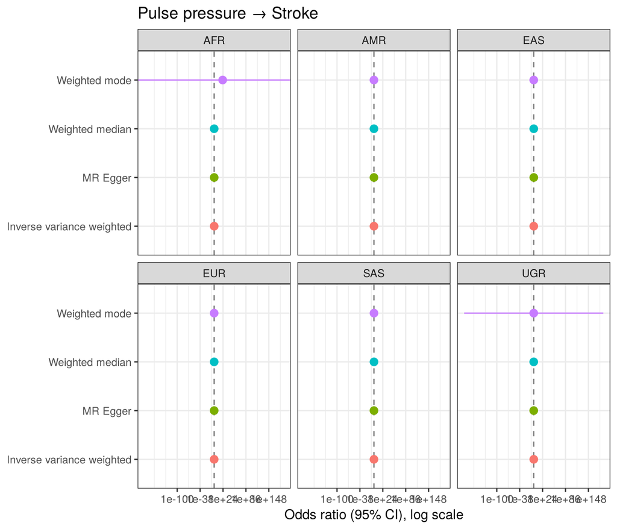

## 4.10 Systolic blood pressure → Coronary heart disease

MR estimates: Systolic blood pressure → Coronary heart disease

| population | outcome_population | method | nsnp | b | se | pval | OR (95% CI) |
| --- | --- | --- | --- | --- | --- | --- | --- |
| AFR | AFR | Inverse variance weighted | 144 | 0.219 | 0.085 | 1.01e-02 | 1.245 (1.053–1.471) |
| AFR | AFR | MR Egger | 144 | 0.046 | 0.132 | 7.29e-01 | 1.047 (0.808–1.357) |
| AFR | AFR | Weighted median | 144 | 0.196 | 0.134 | 1.45e-01 | 1.216 (0.935–1.582) |
| AFR | AFR | Weighted mode | 144 | 0.217 | 2.393 | 9.28e-01 | 1.242 (0.011–135.206) |
| AMR | AMR | Inverse variance weighted | 142 | 0.013 | 0.003 | 1.11e-06 | 1.013 (1.008–1.018) |
| AMR | AMR | MR Egger | 142 | 0.013 | 0.006 | 5.18e-02 | 1.013 (1.000–1.026) |
| AMR | AMR | Weighted median | 142 | 0.013 | 0.004 | 6.72e-04 | 1.013 (1.005–1.020) |
| AMR | AMR | Weighted mode | 142 | 0.017 | 0.006 | 3.44e-03 | 1.017 (1.006–1.029) |
| EAS | EAS | Inverse variance weighted | 141 | 0.046 | 0.006 | 4.48e-15 | 1.047 (1.035–1.060) |
| EAS | EAS | MR Egger | 141 | 0.046 | 0.013 | 4.18e-04 | 1.048 (1.021–1.074) |
| EAS | EAS | Weighted median | 141 | 0.045 | 0.009 | 4.12e-07 | 1.046 (1.028–1.065) |
| EAS | EAS | Weighted mode | 141 | 0.058 | 0.018 | 2.00e-03 | 1.060 (1.022–1.099) |
| EUR | EUR | Inverse variance weighted | 140 | 0.033 | 0.003 | 4.69e-37 | 1.034 (1.029–1.039) |
| EUR | EUR | MR Egger | 140 | 0.026 | 0.008 | 9.19e-04 | 1.026 (1.011–1.042) |
| EUR | EUR | Weighted median | 140 | 0.028 | 0.003 | 8.01e-26 | 1.028 (1.023–1.034) |
| EUR | EUR | Weighted mode | 140 | 0.022 | 0.006 | 1.50e-04 | 1.022 (1.011–1.034) |
| SAS | SAS | Inverse variance weighted | 140 | 0.030 | 0.015 | 5.22e-02 | 1.030 (1.000–1.062) |
| SAS | SAS | MR Egger | 140 | 0.025 | 0.025 | 3.21e-01 | 1.025 (0.976–1.077) |
| SAS | SAS | Weighted median | 140 | 0.028 | 0.023 | 2.30e-01 | 1.029 (0.982–1.077) |
| SAS | SAS | Weighted mode | 140 | 0.031 | 0.427 | 9.43e-01 | 1.031 (0.446–2.382) |
| UGR | AFR | Inverse variance weighted | 143 | 0.099 | 0.081 | 2.23e-01 | 1.104 (0.941–1.295) |
| UGR | AFR | MR Egger | 143 | -0.167 | 0.117 | 1.57e-01 | 0.846 (0.672–1.065) |
| UGR | AFR | Weighted median | 143 | -0.121 | 0.122 | 3.22e-01 | 0.886 (0.698–1.126) |
| UGR | AFR | Weighted mode | 143 | 0.185 | 24.002 | 9.94e-01 | 1.204 (0.000–324699184664289345536.000) |

Cochran’s Q heterogeneity (between SNPs): Systolic blood pressure → Coronary heart disease

| population | method | Q | Q_df | Q_pval |
| --- | --- | --- | --- | --- |
| AFR | MR Egger | 161.15 | 142 | 1.30e-01 |
| AFR | Inverse variance weighted | 164.45 | 143 | 1.06e-01 |
| AMR | MR Egger | 167.47 | 140 | 5.66e-02 |
| AMR | Inverse variance weighted | 167.47 | 141 | 6.35e-02 |
| EAS | MR Egger | 161.30 | 139 | 9.49e-02 |
| EAS | Inverse variance weighted | 161.30 | 140 | 1.05e-01 |
| EUR | MR Egger | 486.87 | 138 | 1.99e-40 |
| EUR | Inverse variance weighted | 490.43 | 139 | 1.04e-40 |
| SAS | MR Egger | 121.29 | 138 | 8.43e-01 |
| SAS | Inverse variance weighted | 121.36 | 139 | 8.57e-01 |
| UGR | MR Egger | 158.84 | 141 | 1.45e-01 |
| UGR | Inverse variance weighted | 169.44 | 142 | 5.79e-02 |

MR-Egger intercept test: Systolic blood pressure → Coronary heart disease

| population | egger_intercept | se | pval |
| --- | --- | --- | --- |
| AFR | 0.2193 | 0.1285 | 9.02e-02 |
| AMR | 0.0001 | 0.0033 | 9.83e-01 |
| EAS | -0.0001 | 0.0069 | 9.92e-01 |
| EUR | 0.0036 | 0.0035 | 3.17e-01 |
| SAS | 0.0060 | 0.0239 | 8.03e-01 |
| UGR | 0.3757 | 0.1225 | 2.59e-03 |

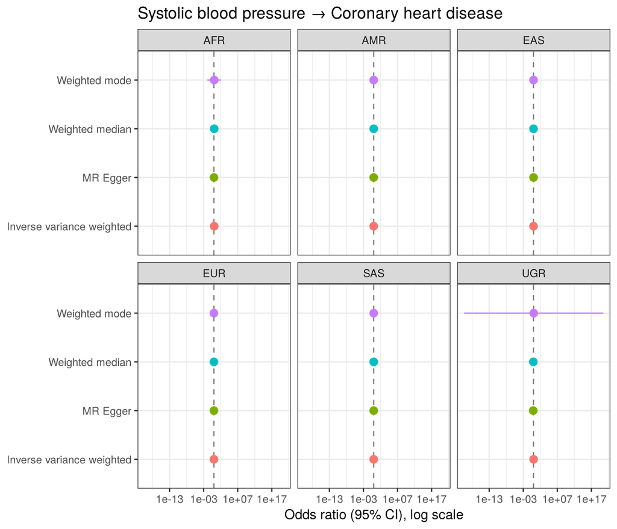

## 4.11 Systolic blood pressure → Hypertension

MR estimates: Systolic blood pressure → Hypertension

| population | outcome_population | method | nsnp | b | se | pval | OR (95% CI) |
| --- | --- | --- | --- | --- | --- | --- | --- |
| AFR | AFR | Inverse variance weighted | 152 | 0.140 | 0.025 | 2.77e-08 | 1.151 (1.095–1.209) |
| AFR | AFR | MR Egger | 152 | 0.093 | 0.039 | 1.95e-02 | 1.098 (1.016–1.186) |
| AFR | AFR | Weighted median | 152 | 0.120 | 0.040 | 2.71e-03 | 1.128 (1.043–1.220) |
| AFR | AFR | Weighted mode | 152 | 0.115 | 1.674 | 9.45e-01 | 1.122 (0.042–29.873) |
| AMR | AMR | Inverse variance weighted | 150 | 0.090 | 0.003 | 6.60e-249 | 1.094 (1.089–1.100) |
| AMR | AMR | MR Egger | 150 | 0.082 | 0.006 | 1.99e-25 | 1.086 (1.072–1.100) |
| AMR | AMR | Weighted median | 150 | 0.083 | 0.004 | 2.78e-78 | 1.086 (1.077–1.096) |
| AMR | AMR | Weighted mode | 150 | 0.094 | 0.009 | 8.80e-20 | 1.099 (1.080–1.119) |
| EAS | EAS | Inverse variance weighted | 149 | 0.160 | 0.021 | 9.88e-15 | 1.173 (1.127–1.222) |
| EAS | EAS | MR Egger | 149 | 0.225 | 0.044 | 1.23e-06 | 1.252 (1.148–1.366) |
| EAS | EAS | Weighted median | 149 | 0.265 | 0.014 | 1.35e-79 | 1.303 (1.268–1.339) |
| EAS | EAS | Weighted mode | 149 | 0.283 | 0.015 | 4.39e-42 | 1.327 (1.289–1.366) |
| EUR | EUR | Inverse variance weighted | 148 | 0.067 | 0.002 | 6.01e-249 | 1.069 (1.065–1.073) |
| EUR | EUR | MR Egger | 148 | 0.070 | 0.006 | 4.74e-24 | 1.072 (1.060–1.085) |
| EUR | EUR | Weighted median | 148 | 0.060 | 0.002 | 4.62e-188 | 1.062 (1.058–1.066) |
| EUR | EUR | Weighted mode | 148 | 0.057 | 0.004 | 3.13e-30 | 1.059 (1.051–1.067) |
| SAS | SAS | Inverse variance weighted | 148 | 0.825 | 0.169 | 1.01e-06 | 2.283 (1.640–3.178) |
| SAS | SAS | MR Egger | 148 | 0.613 | 0.273 | 2.64e-02 | 1.847 (1.081–3.156) |
| SAS | SAS | Weighted median | 148 | 0.470 | 0.252 | 6.19e-02 | 1.601 (0.977–2.623) |
| SAS | SAS | Weighted mode | 148 | 0.242 | 13.411 | 9.86e-01 | 1.274 (0.000–331399024404.954) |
| UGR | AFR | Inverse variance weighted | 151 | 0.058 | 0.024 | 1.47e-02 | 1.060 (1.011–1.110) |
| UGR | AFR | MR Egger | 151 | -0.029 | 0.035 | 4.13e-01 | 0.971 (0.906–1.041) |
| UGR | AFR | Weighted median | 151 | 0.037 | 0.045 | 4.14e-01 | 1.037 (0.950–1.132) |
| UGR | AFR | Weighted mode | 151 | -0.120 | 13.225 | 9.93e-01 | 0.887 (0.000–160269499659.795) |

Cochran’s Q heterogeneity (between SNPs): Systolic blood pressure → Hypertension

| population | method | Q | Q_df | Q_pval |
| --- | --- | --- | --- | --- |
| AFR | MR Egger | 128.49 | 150 | 8.98e-01 |
| AFR | Inverse variance weighted | 130.91 | 151 | 8.80e-01 |
| AMR | MR Egger | 209.98 | 148 | 6.13e-04 |
| AMR | Inverse variance weighted | 212.43 | 149 | 5.00e-04 |
| EAS | MR Egger | 1256.46 | 147 | 2.30e-175 |
| EAS | Inverse variance weighted | 1279.74 | 148 | 2.26e-179 |
| EUR | MR Egger | 711.57 | 146 | 3.02e-75 |
| EUR | Inverse variance weighted | 713.20 | 147 | 3.51e-75 |
| SAS | MR Egger | 161.87 | 146 | 1.75e-01 |
| SAS | Inverse variance weighted | 162.95 | 147 | 1.74e-01 |
| UGR | MR Egger | 141.01 | 149 | 6.67e-01 |
| UGR | Inverse variance weighted | 151.79 | 150 | 4.44e-01 |

MR-Egger intercept test: Systolic blood pressure → Hypertension

| population | egger_intercept | se | pval |
| --- | --- | --- | --- |
| AFR | 0.0592 | 0.0381 | 1.22e-01 |
| AMR | 0.0043 | 0.0033 | 1.91e-01 |
| EAS | -0.0391 | 0.0237 | 1.01e-01 |
| EUR | -0.0015 | 0.0026 | 5.65e-01 |
| SAS | 0.2615 | 0.2652 | 3.26e-01 |
| UGR | 0.1211 | 0.0369 | 1.27e-03 |

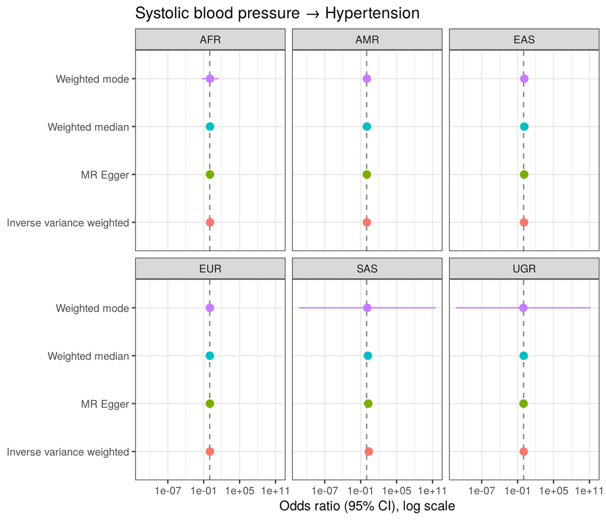

## 4.12 Systolic blood pressure → Stroke

MR estimates: Systolic blood pressure → Stroke

| population | outcome_population | method | nsnp | b | se | pval | OR (95% CI) |
| --- | --- | --- | --- | --- | --- | --- | --- |
| AFR | AFR | Inverse variance weighted | 152 | 0.435 | 0.111 | 8.40e-05 | 1.545 (1.244–1.919) |
| AFR | AFR | MR Egger | 152 | -0.054 | 0.170 | 7.50e-01 | 0.947 (0.679–1.322) |
| AFR | AFR | Weighted median | 152 | 0.362 | 0.173 | 3.65e-02 | 1.436 (1.023–2.015) |
| AFR | AFR | Weighted mode | 152 | 0.298 | 2.769 | 9.14e-01 | 1.347 (0.006–306.552) |
| AMR | AMR | Inverse variance weighted | 150 | 0.071 | 0.011 | 1.68e-11 | 1.073 (1.051–1.096) |
| AMR | AMR | MR Egger | 150 | 0.084 | 0.026 | 1.22e-03 | 1.088 (1.035–1.144) |
| AMR | AMR | Weighted median | 150 | 0.069 | 0.016 | 1.16e-05 | 1.071 (1.039–1.105) |
| AMR | AMR | Weighted mode | 150 | 0.077 | 0.029 | 9.07e-03 | 1.080 (1.020–1.143) |
| EAS | EAS | Inverse variance weighted | 148 | 0.215 | 0.016 | 5.40e-41 | 1.240 (1.201–1.279) |
| EAS | EAS | MR Egger | 148 | 0.258 | 0.035 | 7.01e-12 | 1.295 (1.210–1.386) |
| EAS | EAS | Weighted median | 148 | 0.223 | 0.023 | 1.23e-21 | 1.250 (1.194–1.308) |
| EAS | EAS | Weighted mode | 148 | 0.299 | 0.132 | 2.51e-02 | 1.348 (1.041–1.747) |
| EUR | EUR | Inverse variance weighted | 148 | 0.036 | 0.003 | 1.63e-35 | 1.036 (1.031–1.042) |
| EUR | EUR | MR Egger | 148 | 0.036 | 0.008 | 2.54e-05 | 1.037 (1.020–1.054) |
| EUR | EUR | Weighted median | 148 | 0.032 | 0.003 | 1.78e-27 | 1.033 (1.027–1.039) |
| EUR | EUR | Weighted mode | 148 | 0.034 | 0.006 | 3.06e-08 | 1.034 (1.023–1.046) |
| SAS | SAS | Inverse variance weighted | 148 | 0.061 | 0.039 | 1.21e-01 | 1.063 (0.984–1.149) |
| SAS | SAS | MR Egger | 148 | 0.100 | 0.064 | 1.19e-01 | 1.106 (0.975–1.253) |
| SAS | SAS | Weighted median | 148 | 0.102 | 0.058 | 8.05e-02 | 1.107 (0.988–1.241) |
| SAS | SAS | Weighted mode | 148 | 0.149 | 1.885 | 9.37e-01 | 1.160 (0.029–46.683) |
| UGR | AFR | Inverse variance weighted | 151 | 0.140 | 0.108 | 1.94e-01 | 1.151 (0.931–1.422) |
| UGR | AFR | MR Egger | 151 | -0.329 | 0.155 | 3.54e-02 | 0.720 (0.532–0.975) |
| UGR | AFR | Weighted median | 151 | 0.024 | 0.188 | 9.00e-01 | 1.024 (0.709–1.479) |
| UGR | AFR | Weighted mode | 151 | 0.400 | 29.600 | 9.89e-01 | 1.492 (0.000–23436441579512090431848448.000) |

Cochran’s Q heterogeneity (between SNPs): Systolic blood pressure → Stroke

| population | method | Q | Q_df | Q_pval |
| --- | --- | --- | --- | --- |
| AFR | MR Egger | 142.14 | 150 | 6.64e-01 |
| AFR | Inverse variance weighted | 156.16 | 151 | 3.70e-01 |
| AMR | MR Egger | 146.46 | 148 | 5.20e-01 |
| AMR | Inverse variance weighted | 146.80 | 149 | 5.36e-01 |
| EAS | MR Egger | 196.14 | 146 | 3.56e-03 |
| EAS | Inverse variance weighted | 198.84 | 147 | 2.85e-03 |
| EUR | MR Egger | 427.37 | 146 | 2.15e-29 |
| EUR | Inverse variance weighted | 427.38 | 147 | 3.68e-29 |
| SAS | MR Egger | 167.99 | 146 | 1.03e-01 |
| SAS | Inverse variance weighted | 168.69 | 147 | 1.06e-01 |
| UGR | MR Egger | 153.30 | 149 | 3.88e-01 |
| UGR | Inverse variance weighted | 170.23 | 150 | 1.24e-01 |

MR-Egger intercept test: Systolic blood pressure → Stroke

| population | egger_intercept | se | pval |
| --- | --- | --- | --- |
| AFR | 0.6149 | 0.1642 | 2.57e-04 |
| AMR | -0.0076 | 0.0131 | 5.62e-01 |
| EAS | -0.0261 | 0.0184 | 1.58e-01 |
| EUR | -0.0002 | 0.0038 | 9.57e-01 |
| SAS | -0.0484 | 0.0620 | 4.37e-01 |
| UGR | 0.6535 | 0.1611 | 8.01e-05 |

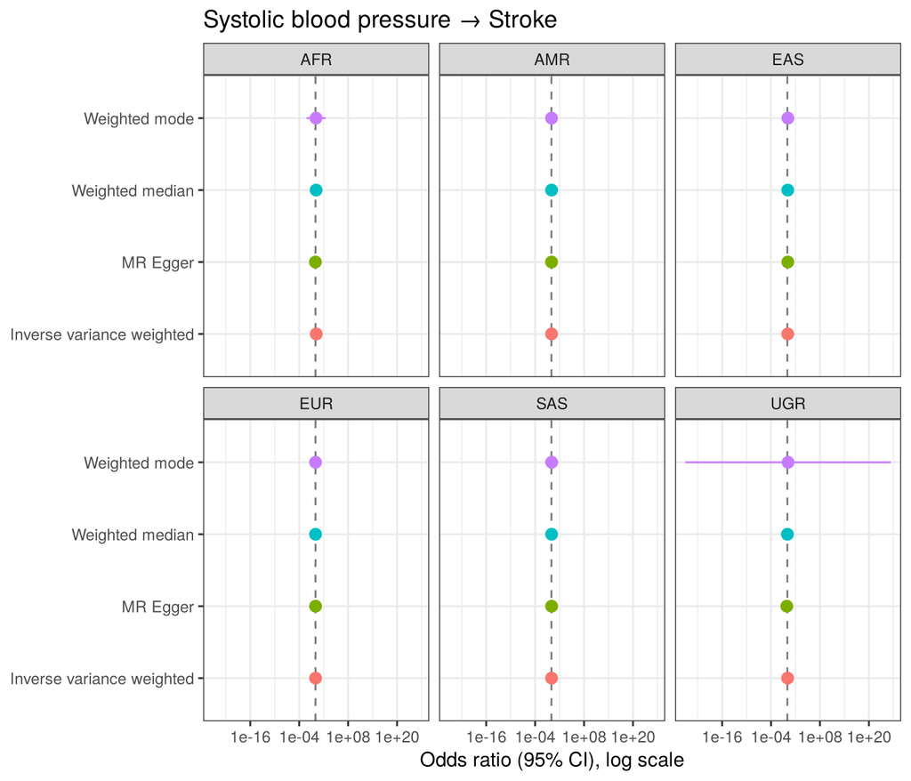

# 5 Drug-class MR

Each drug class uses only the instruments annotated with that class in the exposure file’s `Drug` column. Classes with one SNP give a Wald ratio only. MR-Egger, weighted median and weighted mode need at least three SNPs.

Drug-class instruments kept for MR

| exposure | outcome | drug_class_analysis | target_genes | snps_per_population |
| --- | --- | --- | --- | --- |
| Diastolic blood pressure | Coronary heart disease | ACEI | ACE | 1 |
| Diastolic blood pressure | Coronary heart disease | BB | ADRB1 | 2 |
| Diastolic blood pressure | Coronary heart disease | CCB | CACNA1C, CACNA1D, CACNA2D2, CACNB2, CACNB3 | 10 |
| Diastolic blood pressure | Hypertension | ACEI | ACE | 1 |
| Diastolic blood pressure | Hypertension | BB | ADRB1 | 2 |
| Diastolic blood pressure | Hypertension | CCB | CACNA1C, CACNA1D, CACNA2D2, CACNB2, CACNB3 | 10 |
| Diastolic blood pressure | Stroke | ACEI | ACE | 1 |
| Diastolic blood pressure | Stroke | BB | ADRB1 | 2 |
| Diastolic blood pressure | Stroke | CCB | CACNA1C, CACNA1D, CACNA2D2, CACNB2, CACNB3 | 10 |
| LDL cholesterol | Coronary heart disease | Ezetimibe | NPC1L1 | 12 |
| LDL cholesterol | Coronary heart disease | Statins | HMGCR, PCSK9 | 53–54 |
| LDL cholesterol | Hypertension | Ezetimibe | NPC1L1 | 2 |
| LDL cholesterol | Hypertension | Statins | HMGCR, PCSK9 | 7–8 |
| LDL cholesterol | Stroke | Ezetimibe | NPC1L1 | 2 |
| LDL cholesterol | Stroke | Statins | HMGCR, PCSK9 | 7–8 |
| Pulse pressure | Coronary heart disease | BB | ADRB1 | 1 |
| Pulse pressure | Coronary heart disease | CCB | CACNA1C, CACNA1D, CACNB2, CACNB3, CACNG1 | 9–10 |
| Pulse pressure | Hypertension | BB | ADRB1 | 1 |
| Pulse pressure | Hypertension | CCB | CACNA1C, CACNA1D, CACNB2, CACNB3, CACNG1 | 9–10 |
| Pulse pressure | Stroke | BB | ADRB1 | 1 |
| Pulse pressure | Stroke | CCB | CACNA1C, CACNA1D, CACNB2, CACNB3, CACNG1 | 9–10 |
| Systolic blood pressure | Coronary heart disease | CCB | CACNA1D, CACNB2 | 2 |
| Systolic blood pressure | Hypertension | ACEI | ACE | 1 |
| Systolic blood pressure | Hypertension | BB | ADRB1 | 2 |
| Systolic blood pressure | Hypertension | CCB | CACNA1C, CACNA1D, CACNB2, CACNB3 | 7 |
| Systolic blood pressure | Stroke | ACEI | ACE | 1 |
| Systolic blood pressure | Stroke | BB | ADRB1 | 2 |
| Systolic blood pressure | Stroke | CCB | CACNA1C, CACNA1D, CACNB2, CACNB3 | 7 |

## 5.1 Cross-ancestry IVW estimates by drug class

Cross-ancestry IVW MR estimates by drug class

| exposure | outcome | drug class | k | OR fixed (95% CI) | p_fixed | OR random (95% CI) | p_random | Q | Q_pval | I2 |
| --- | --- | --- | --- | --- | --- | --- | --- | --- | --- | --- |
| Diastolic blood pressure | Coronary heart disease | ACEI | 6 | 1.038 (0.980–1.099) | 1.99e-01 | 1.038 (0.980–1.099) | 1.99e-01 | 4.77 | 4.44e-01 | 0% |
| Diastolic blood pressure | Coronary heart disease | BB | 6 | 1.044 (1.006–1.083) | 2.41e-02 | 1.044 (1.006–1.083) | 2.41e-02 | 4.12 | 5.32e-01 | 0% |
| Diastolic blood pressure | Coronary heart disease | CCB | 6 | 1.036 (1.014–1.058) | 1.18e-03 | 1.036 (1.014–1.058) | 1.18e-03 | 2.28 | 8.09e-01 | 0% |
| Diastolic blood pressure | Hypertension | ACEI | 6 | 1.192 (1.147–1.238) | 1.81e-19 | 1.064 (0.776–1.459) | 6.98e-01 | 15.67 | 7.84e-03 | 68% |
| Diastolic blood pressure | Hypertension | BB | 6 | 1.132 (1.105–1.161) | 7.40e-23 | 0.990 (0.819–1.196) | 9.14e-01 | 40.51 | 1.18e-07 | 88% |
| Diastolic blood pressure | Hypertension | CCB | 6 | 1.123 (1.098–1.148) | 1.02e-24 | 1.171 (1.062–1.290) | 1.47e-03 | 28.79 | 2.54e-05 | 83% |
| Diastolic blood pressure | Stroke | ACEI | 6 | 1.124 (1.045–1.208) | 1.54e-03 | 1.248 (0.894–1.741) | 1.92e-01 | 5.40 | 3.70e-01 | 7% |
| Diastolic blood pressure | Stroke | BB | 6 | 1.047 (0.998–1.100) | 6.18e-02 | 1.047 (0.998–1.100) | 6.18e-02 | 1.11 | 9.53e-01 | 0% |
| Diastolic blood pressure | Stroke | CCB | 6 | 1.047 (1.014–1.081) | 4.60e-03 | 1.097 (0.875–1.375) | 4.21e-01 | 14.38 | 1.34e-02 | 65% |
| LDL cholesterol | Coronary heart disease | Ezetimibe | 6 | 1.297 (0.974–1.727) | 7.53e-02 | 1.452 (0.621–3.399) | 3.90e-01 | 14.96 | 1.05e-02 | 67% |
| LDL cholesterol | Coronary heart disease | Statins | 6 | 1.180 (1.105–1.261) | 7.27e-07 | 1.169 (0.757–1.807) | 4.81e-01 | 90.64 | 4.93e-18 | 94% |
| LDL cholesterol | Hypertension | Ezetimibe | 6 | 1.579 (1.032–2.417) | 3.54e-02 | 1.579 (1.032–2.417) | 3.54e-02 | 1.51 | 9.12e-01 | 0% |
| LDL cholesterol | Hypertension | Statins | 6 | 1.009 (0.927–1.098) | 8.35e-01 | 0.958 (0.747–1.229) | 7.38e-01 | 11.57 | 4.12e-02 | 57% |
| LDL cholesterol | Stroke | Ezetimibe | 6 | 2.804 (1.396–5.630) | 3.74e-03 | 2.804 (1.396–5.630) | 3.74e-03 | 2.93 | 7.11e-01 | 0% |
| LDL cholesterol | Stroke | Statins | 6 | 1.476 (1.140–1.911) | 3.15e-03 | 1.032 (0.422–2.524) | 9.45e-01 | 11.44 | 4.33e-02 | 56% |
| Pulse pressure | Coronary heart disease | BB | 6 | 0.996 (0.949–1.046) | 8.73e-01 | 0.996 (0.949–1.046) | 8.73e-01 | 2.59 | 7.63e-01 | 0% |
| Pulse pressure | Coronary heart disease | CCB | 6 | 1.024 (1.006–1.043) | 1.07e-02 | 1.024 (1.002–1.046) | 3.54e-02 | 5.51 | 3.57e-01 | 9% |
| Pulse pressure | Hypertension | BB | 6 | 1.110 (1.064–1.158) | 1.40e-06 | 1.371 (1.087–1.729) | 7.64e-03 | 49.37 | 1.86e-09 | 90% |
| Pulse pressure | Hypertension | CCB | 6 | 1.107 (1.075–1.140) | 1.98e-11 | 1.175 (1.076–1.282) | 3.08e-04 | 17.50 | 3.64e-03 | 71% |
| Pulse pressure | Stroke | BB | 6 | 1.161 (1.032–1.307) | 1.32e-02 | 1.184 (1.010–1.388) | 3.69e-02 | 5.74 | 3.33e-01 | 13% |
| Pulse pressure | Stroke | CCB | 6 | 1.039 (1.002–1.077) | 3.73e-02 | 1.070 (0.976–1.173) | 1.48e-01 | 6.72 | 2.42e-01 | 26% |
| Systolic blood pressure | Coronary heart disease | CCB | 6 | 1.018 (0.995–1.042) | 1.18e-01 | 1.018 (0.995–1.042) | 1.18e-01 | 3.48 | 6.26e-01 | 0% |
| Systolic blood pressure | Hypertension | ACEI | 6 | 1.113 (1.087–1.139) | 6.37e-19 | 1.039 (0.852–1.266) | 7.08e-01 | 18.16 | 2.75e-03 | 72% |
| Systolic blood pressure | Hypertension | BB | 6 | 1.068 (1.036–1.101) | 2.21e-05 | 1.133 (1.039–1.235) | 4.79e-03 | 15.44 | 8.62e-03 | 68% |
| Systolic blood pressure | Hypertension | CCB | 6 | 1.076 (1.063–1.088) | 1.28e-34 | 1.088 (1.046–1.131) | 2.92e-05 | 13.48 | 1.93e-02 | 63% |
| Systolic blood pressure | Stroke | ACEI | 6 | 1.076 (1.029–1.125) | 1.29e-03 | 1.088 (1.000–1.183) | 4.88e-02 | 5.07 | 4.08e-01 | 1% |
| Systolic blood pressure | Stroke | BB | 6 | 1.030 (0.990–1.073) | 1.47e-01 | 1.030 (0.990–1.073) | 1.47e-01 | 4.98 | 4.18e-01 | 0% |
| Systolic blood pressure | Stroke | CCB | 6 | 1.031 (1.008–1.056) | 8.81e-03 | 1.049 (0.983–1.120) | 1.48e-01 | 6.16 | 2.91e-01 | 19% |

### 5.1.1 Diastolic blood pressure

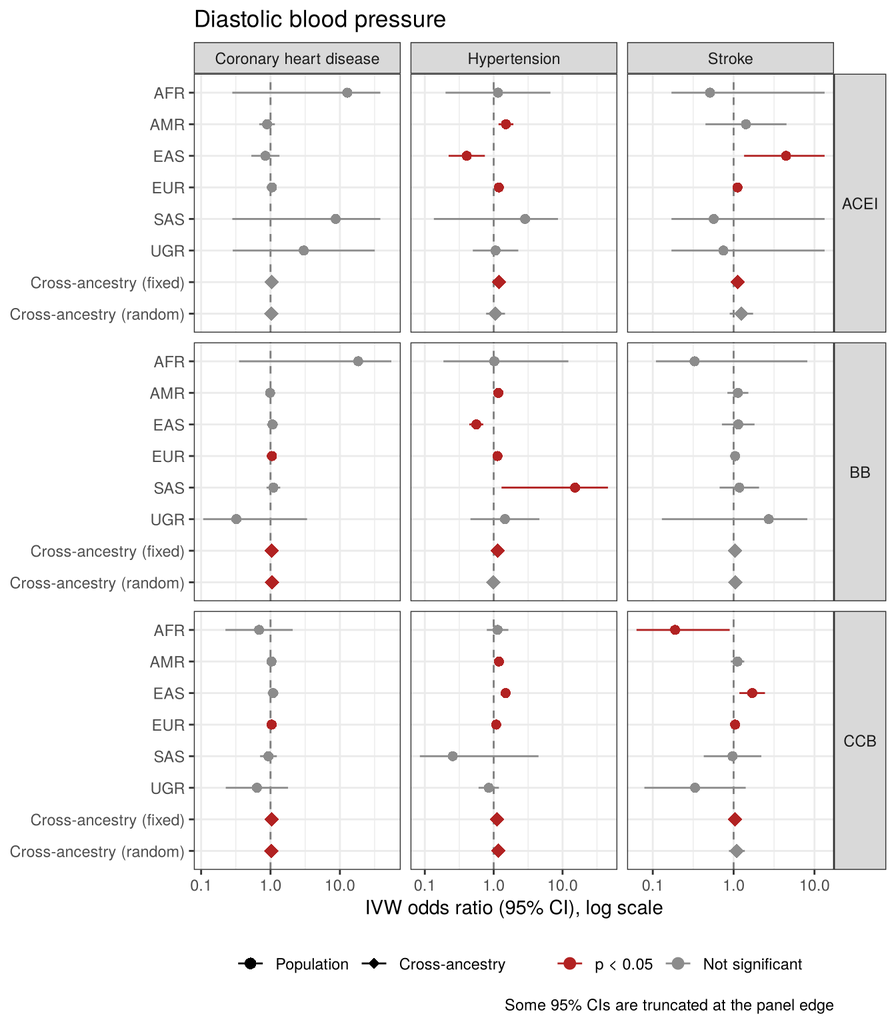

### 5.1.2 LDL cholesterol

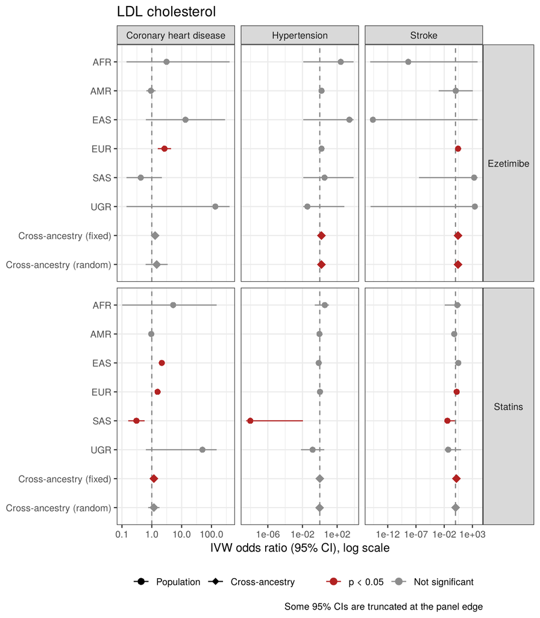

### 5.1.3 Pulse pressure

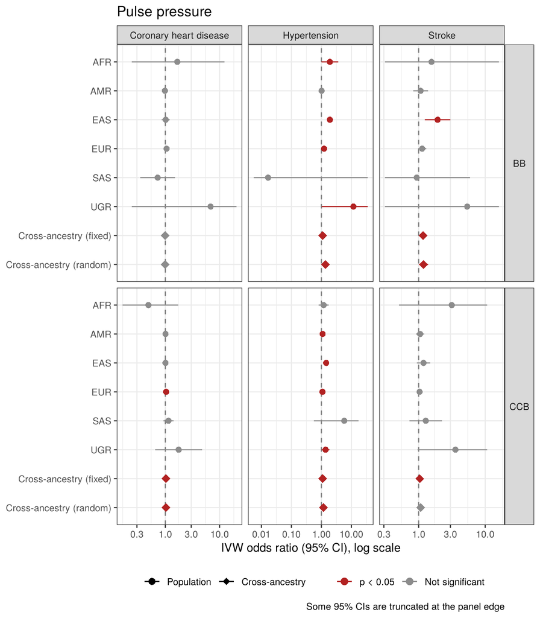

### 5.1.4 Systolic blood pressure

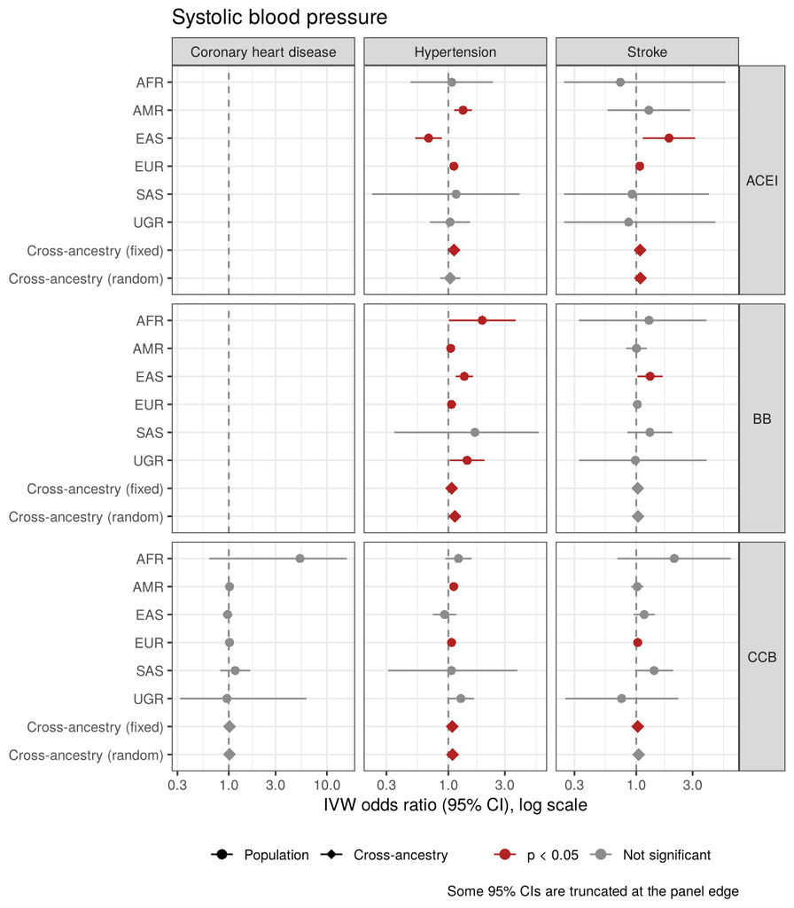

## 5.2 Drug-class results by exposure–outcome pair

### 5.2.1 Diastolic blood pressure → Coronary heart disease (BB)

MR estimates: Diastolic blood pressure → Coronary heart disease (BB)

| population | outcome_population | method | nsnp | b | se | pval | OR (95% CI) |
| --- | --- | --- | --- | --- | --- | --- | --- |
| AFR | AFR | Inverse variance weighted | 2 | 2.910 | 2.017 | 1.49e-01 | 18.366 (0.352–957.156) |
| AMR | AMR | Inverse variance weighted | 2 | -0.015 | 0.063 | 8.15e-01 | 0.985 (0.871–1.115) |
| EAS | EAS | Inverse variance weighted | 2 | 0.066 | 0.092 | 4.70e-01 | 1.069 (0.892–1.280) |
| EUR | EUR | Inverse variance weighted | 2 | 0.046 | 0.021 | 2.57e-02 | 1.047 (1.006–1.091) |
| SAS | SAS | Inverse variance weighted | 2 | 0.095 | 0.116 | 4.10e-01 | 1.100 (0.877–1.380) |
| UGR | AFR | Inverse variance weighted | 2 | -1.134 | 1.197 | 3.44e-01 | 0.322 (0.031–3.363) |

Cochran’s Q heterogeneity (between SNPs): Diastolic blood pressure → Coronary heart disease (BB)

| population | method | Q | Q_df | Q_pval |
| --- | --- | --- | --- | --- |
| AFR | Inverse variance weighted | 0.11 | 1 | 7.37e-01 |
| AMR | Inverse variance weighted | 4.59 | 1 | 3.22e-02 |
| EAS | Inverse variance weighted | 0.13 | 1 | 7.21e-01 |
| EUR | Inverse variance weighted | 0.01 | 1 | 9.31e-01 |
| SAS | Inverse variance weighted | 0.05 | 1 | 8.18e-01 |
| UGR | Inverse variance weighted | 1.16 | 1 | 2.82e-01 |

MR-Egger intercept test: Diastolic blood pressure → Coronary heart disease (BB)

| population | egger_intercept | se | pval |
| --- | --- | --- | --- |
| AFR | NA | NA | NA |
| AMR | NA | NA | NA |
| EAS | NA | NA | NA |
| EUR | NA | NA | NA |
| SAS | NA | NA | NA |
| UGR | NA | NA | NA |

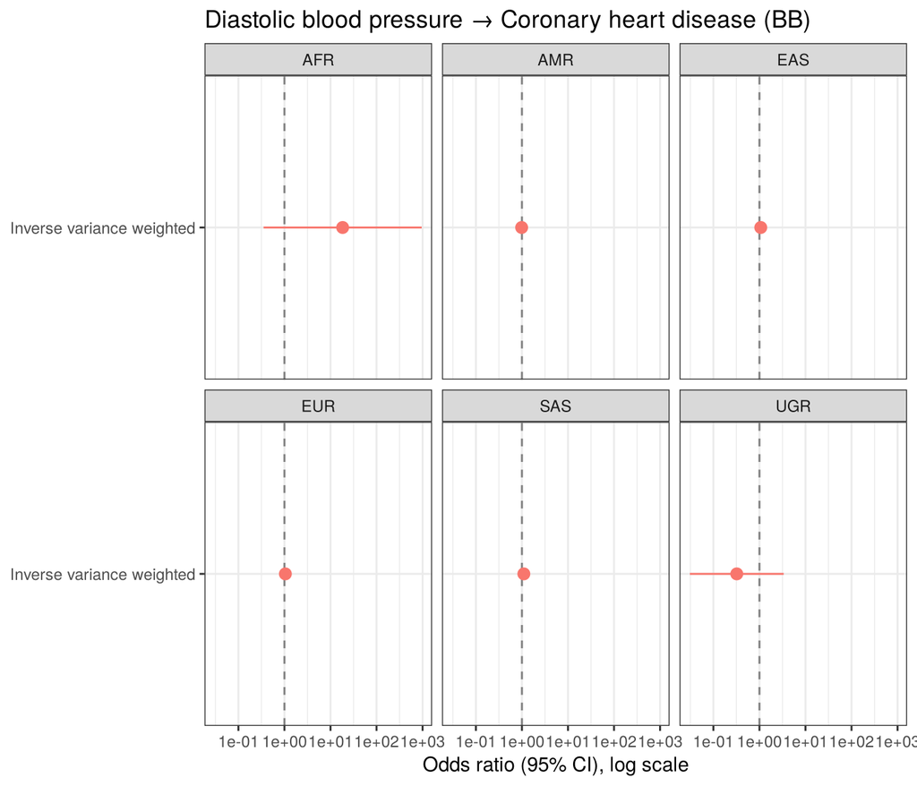

### 5.2.2 Diastolic blood pressure → Coronary heart disease (CCB)

MR estimates: Diastolic blood pressure → Coronary heart disease (CCB)

| population | outcome_population | method | nsnp | b | se | pval | OR (95% CI) |
| --- | --- | --- | --- | --- | --- | --- | --- |
| AFR | AFR | Inverse variance weighted | 10 | -0.379 | 0.570 | 5.05e-01 | 0.684 (0.224–2.090) |
| AFR | AFR | MR Egger | 10 | -1.086 | 0.824 | 2.24e-01 | 0.337 (0.067–1.698) |
| AFR | AFR | Weighted median | 10 | -0.733 | 0.955 | 4.42e-01 | 0.480 (0.074–3.120) |
| AFR | AFR | Weighted mode | 10 | -0.865 | 0.745 | 2.75e-01 | 0.421 (0.098–1.811) |
| AMR | AMR | Inverse variance weighted | 10 | 0.033 | 0.019 | 8.76e-02 | 1.033 (0.995–1.072) |
| AMR | AMR | MR Egger | 10 | 0.024 | 0.054 | 6.72e-01 | 1.024 (0.922–1.137) |
| AMR | AMR | Weighted median | 10 | 0.019 | 0.025 | 4.45e-01 | 1.019 (0.970–1.071) |
| AMR | AMR | Weighted mode | 10 | 0.022 | 0.032 | 5.13e-01 | 1.022 (0.959–1.089) |
| EAS | EAS | Inverse variance weighted | 10 | 0.086 | 0.090 | 3.39e-01 | 1.090 (0.914–1.300) |
| EAS | EAS | MR Egger | 10 | -0.018 | 0.171 | 9.19e-01 | 0.982 (0.702–1.374) |
| EAS | EAS | Weighted median | 10 | 0.078 | 0.076 | 3.05e-01 | 1.082 (0.931–1.256) |
| EAS | EAS | Weighted mode | 10 | 0.086 | 0.076 | 2.88e-01 | 1.090 (0.939–1.266) |
| EUR | EUR | Inverse variance weighted | 10 | 0.037 | 0.013 | 5.98e-03 | 1.038 (1.011–1.065) |
| EUR | EUR | MR Egger | 10 | 0.061 | 0.031 | 8.54e-02 | 1.063 (1.000–1.129) |
| EUR | EUR | Weighted median | 10 | 0.036 | 0.018 | 4.13e-02 | 1.037 (1.001–1.073) |
| EUR | EUR | Weighted mode | 10 | 0.042 | 0.018 | 3.96e-02 | 1.043 (1.008–1.080) |
| SAS | SAS | Inverse variance weighted | 10 | -0.069 | 0.142 | 6.27e-01 | 0.934 (0.707–1.232) |
| SAS | SAS | MR Egger | 10 | -0.384 | 0.256 | 1.72e-01 | 0.681 (0.412–1.126) |
| SAS | SAS | Weighted median | 10 | -0.006 | 0.337 | 9.86e-01 | 0.994 (0.514–1.924) |
| SAS | SAS | Weighted mode | 10 | -0.071 | 0.193 | 7.22e-01 | 0.932 (0.639–1.359) |
| UGR | AFR | Inverse variance weighted | 10 | -0.452 | 0.527 | 3.91e-01 | 0.637 (0.227–1.788) |
| UGR | AFR | MR Egger | 10 | -0.323 | 0.736 | 6.72e-01 | 0.724 (0.171–3.061) |
| UGR | AFR | Weighted median | 10 | -0.491 | 3.475 | 8.88e-01 | 0.612 (0.001–556.306) |
| UGR | AFR | Weighted mode | 10 | -0.471 | 0.703 | 5.20e-01 | 0.625 (0.158–2.477) |

Cochran’s Q heterogeneity (between SNPs): Diastolic blood pressure → Coronary heart disease (CCB)

| population | method | Q | Q_df | Q_pval |
| --- | --- | --- | --- | --- |
| AFR | MR Egger | 6.93 | 8 | 5.44e-01 |
| AFR | Inverse variance weighted | 8.34 | 9 | 5.00e-01 |
| AMR | MR Egger | 9.17 | 8 | 3.28e-01 |
| AMR | Inverse variance weighted | 9.20 | 9 | 4.19e-01 |
| EAS | MR Egger | 18.61 | 8 | 1.71e-02 |
| EAS | Inverse variance weighted | 19.82 | 9 | 1.91e-02 |
| EUR | MR Egger | 4.60 | 8 | 7.99e-01 |
| EUR | Inverse variance weighted | 5.33 | 9 | 8.04e-01 |
| SAS | MR Egger | 4.80 | 8 | 7.78e-01 |
| SAS | Inverse variance weighted | 6.98 | 9 | 6.39e-01 |
| UGR | MR Egger | 7.99 | 8 | 4.35e-01 |
| UGR | Inverse variance weighted | 8.05 | 9 | 5.29e-01 |

MR-Egger intercept test: Diastolic blood pressure → Coronary heart disease (CCB)

| population | egger_intercept | se | pval |
| --- | --- | --- | --- |
| AFR | 0.4835 | 0.4076 | 2.70e-01 |
| AMR | 0.0024 | 0.0136 | 8.62e-01 |
| EAS | 0.0247 | 0.0343 | 4.91e-01 |
| EUR | -0.0052 | 0.0061 | 4.17e-01 |
| SAS | 0.1583 | 0.1073 | 1.78e-01 |
| UGR | -0.0985 | 0.3931 | 8.08e-01 |

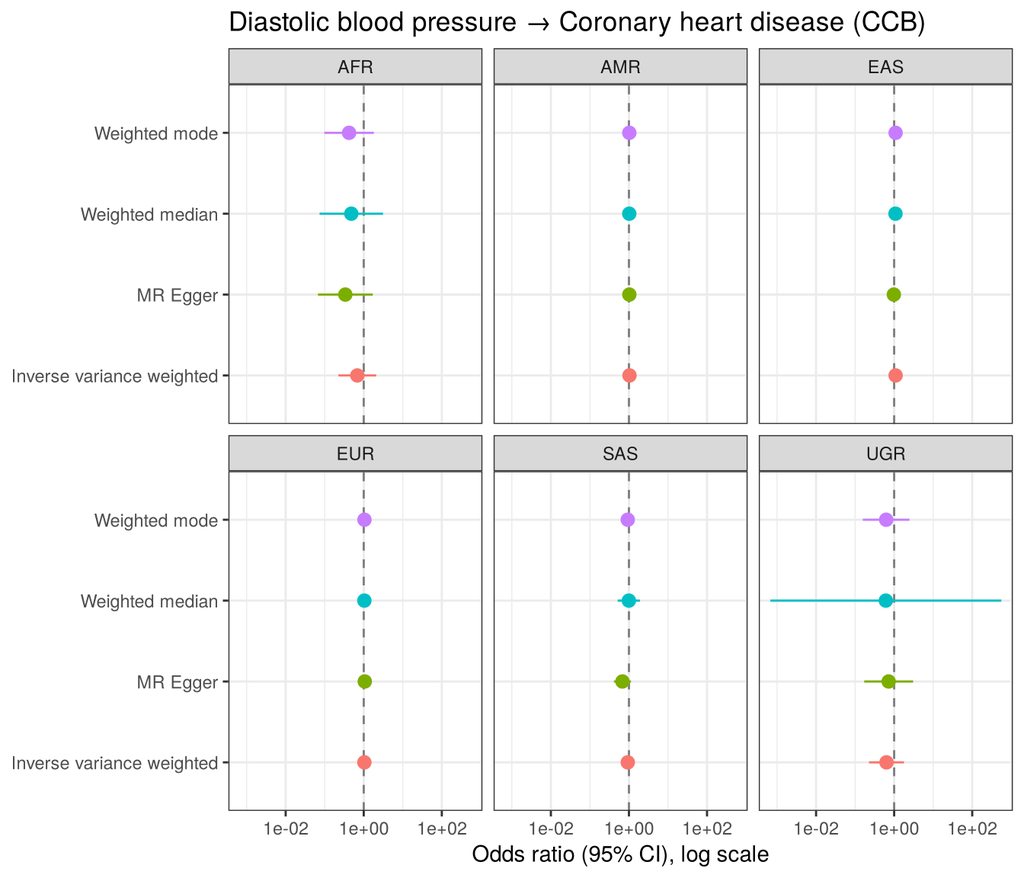

### 5.2.3 Diastolic blood pressure → Coronary heart disease (ACEI)

MR estimates: Diastolic blood pressure → Coronary heart disease (ACEI)

| population | outcome_population | method | nsnp | b | se | pval | OR (95% CI) |
| --- | --- | --- | --- | --- | --- | --- | --- |
| AFR | AFR | Wald ratio | 1 | 2.546 | 2.773 | 3.59e-01 | 12.750 (0.056–2925.600) |
| AMR | AMR | Wald ratio | 1 | -0.115 | 0.132 | 3.86e-01 | 0.892 (0.688–1.156) |
| EAS | EAS | Wald ratio | 1 | -0.169 | 0.238 | 4.77e-01 | 0.844 (0.530–1.346) |
| EUR | EUR | Wald ratio | 1 | 0.047 | 0.030 | 1.17e-01 | 1.048 (0.988–1.112) |
| SAS | SAS | Wald ratio | 1 | 2.162 | 2.141 | 3.13e-01 | 8.690 (0.131–577.796) |
| UGR | AFR | Wald ratio | 1 | 1.104 | 1.202 | 3.59e-01 | 3.015 (0.286–31.816) |

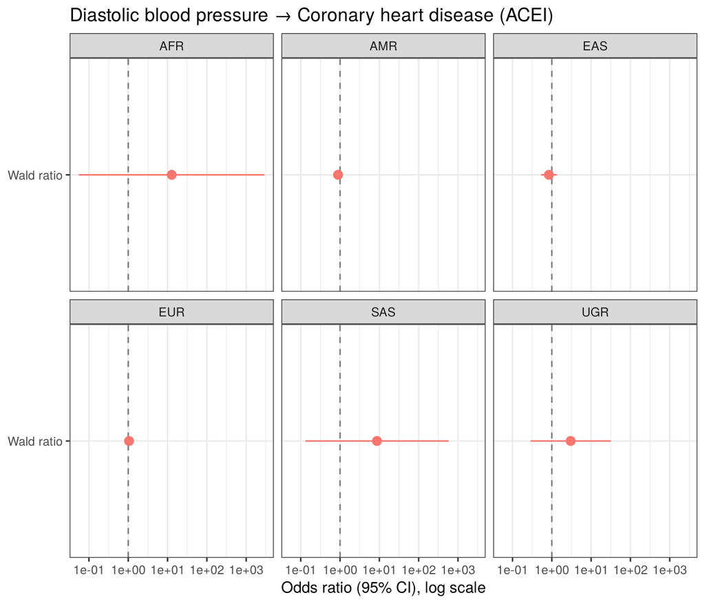

### 5.2.4 Diastolic blood pressure → Hypertension (BB)

MR estimates: Diastolic blood pressure → Hypertension (BB)

| population | outcome_population | method | nsnp | b | se | pval | OR (95% CI) |
| --- | --- | --- | --- | --- | --- | --- | --- |
| AFR | AFR | Inverse variance weighted | 2 | 0.019 | 1.264 | 9.88e-01 | 1.020 (0.086–12.143) |
| AMR | AMR | Inverse variance weighted | 2 | 0.155 | 0.037 | 2.54e-05 | 1.168 (1.087–1.256) |
| EAS | EAS | Inverse variance weighted | 2 | -0.582 | 0.119 | 1.01e-06 | 0.559 (0.443–0.706) |
| EUR | EUR | Inverse variance weighted | 2 | 0.129 | 0.014 | 1.73e-21 | 1.138 (1.108–1.168) |
| SAS | SAS | Inverse variance weighted | 2 | 2.722 | 1.255 | 3.01e-02 | 15.215 (1.301–178.007) |
| UGR | AFR | Inverse variance weighted | 2 | 0.376 | 0.588 | 5.23e-01 | 1.456 (0.460–4.612) |

Cochran’s Q heterogeneity (between SNPs): Diastolic blood pressure → Hypertension (BB)

| population | method | Q | Q_df | Q_pval |
| --- | --- | --- | --- | --- |
| AFR | Inverse variance weighted | 3.81 | 1 | 5.10e-02 |
| AMR | Inverse variance weighted | 1.71 | 1 | 1.91e-01 |
| EAS | Inverse variance weighted | 0.35 | 1 | 5.52e-01 |
| EUR | Inverse variance weighted | 0.88 | 1 | 3.49e-01 |
| SAS | Inverse variance weighted | 0.07 | 1 | 7.87e-01 |
| UGR | Inverse variance weighted | 2.71 | 1 | 9.99e-02 |

MR-Egger intercept test: Diastolic blood pressure → Hypertension (BB)

| population | egger_intercept | se | pval |
| --- | --- | --- | --- |
| AFR | NA | NA | NA |
| AMR | NA | NA | NA |
| EAS | NA | NA | NA |
| EUR | NA | NA | NA |
| SAS | NA | NA | NA |
| UGR | NA | NA | NA |

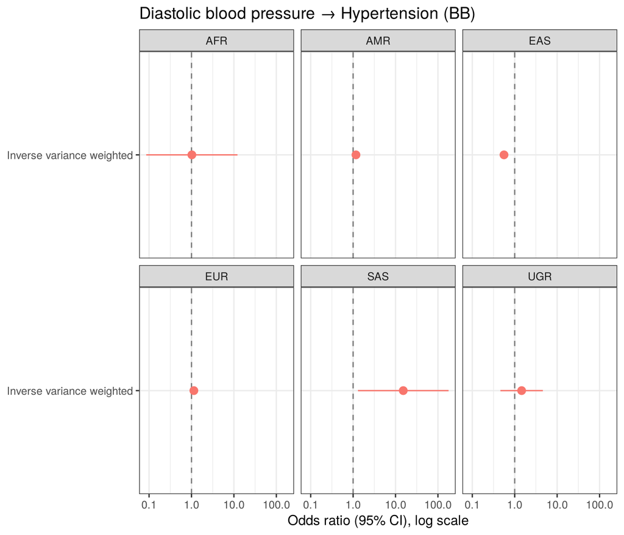

### 5.2.5 Diastolic blood pressure → Hypertension (CCB)

MR estimates: Diastolic blood pressure → Hypertension (CCB)

| population | outcome_population | method | nsnp | b | se | pval | OR (95% CI) |
| --- | --- | --- | --- | --- | --- | --- | --- |
| AFR | AFR | Inverse variance weighted | 10 | 0.130 | 0.184 | 4.79e-01 | 1.139 (0.794–1.634) |
| AFR | AFR | MR Egger | 10 | 0.217 | 0.266 | 4.38e-01 | 1.243 (0.738–2.093) |
| AFR | AFR | Weighted median | 10 | 0.221 | 0.267 | 4.08e-01 | 1.247 (0.739–2.103) |
| AFR | AFR | Weighted mode | 10 | 0.226 | 0.217 | 3.24e-01 | 1.253 (0.820–1.917) |
| AMR | AMR | Inverse variance weighted | 10 | 0.176 | 0.021 | 1.07e-16 | 1.192 (1.144–1.243) |
| AMR | AMR | MR Egger | 10 | 0.169 | 0.060 | 2.28e-02 | 1.184 (1.052–1.332) |
| AMR | AMR | Weighted median | 10 | 0.192 | 0.032 | 1.59e-09 | 1.211 (1.138–1.289) |
| AMR | AMR | Weighted mode | 10 | 0.191 | 0.044 | 1.92e-03 | 1.210 (1.110–1.319) |
| EAS | EAS | Inverse variance weighted | 10 | 0.399 | 0.081 | 9.27e-07 | 1.491 (1.271–1.749) |
| EAS | EAS | MR Egger | 10 | 0.566 | 0.146 | 4.75e-03 | 1.761 (1.322–2.345) |
| EAS | EAS | Weighted median | 10 | 0.488 | 0.117 | 2.92e-05 | 1.628 (1.296–2.047) |
| EAS | EAS | Weighted mode | 10 | 0.493 | 0.120 | 2.69e-03 | 1.638 (1.294–2.074) |
| EUR | EUR | Inverse variance weighted | 10 | 0.085 | 0.014 | 4.19e-10 | 1.089 (1.060–1.118) |
| EUR | EUR | MR Egger | 10 | 0.111 | 0.032 | 7.96e-03 | 1.118 (1.050–1.189) |
| EUR | EUR | Weighted median | 10 | 0.076 | 0.017 | 6.98e-06 | 1.079 (1.044–1.115) |
| EUR | EUR | Weighted mode | 10 | 0.067 | 0.025 | 2.72e-02 | 1.069 (1.017–1.124) |
| SAS | SAS | Inverse variance weighted | 10 | -1.369 | 1.528 | 3.70e-01 | 0.254 (0.013–5.082) |
| SAS | SAS | MR Egger | 10 | -0.976 | 2.769 | 7.34e-01 | 0.377 (0.002–85.671) |
| SAS | SAS | Weighted median | 10 | -1.653 | 5.042 | 7.43e-01 | 0.191 (0.000–3747.542) |
| SAS | SAS | Weighted mode | 10 | -1.503 | 2.156 | 5.03e-01 | 0.222 (0.003–15.220) |
| UGR | AFR | Inverse variance weighted | 10 | -0.165 | 0.173 | 3.41e-01 | 0.848 (0.604–1.191) |
| UGR | AFR | MR Egger | 10 | -0.383 | 0.244 | 1.55e-01 | 0.682 (0.423–1.099) |
| UGR | AFR | Weighted median | 10 | -0.213 | 0.893 | 8.12e-01 | 0.808 (0.140–4.654) |
| UGR | AFR | Weighted mode | 10 | -0.211 | 0.216 | 3.54e-01 | 0.809 (0.530–1.236) |

Cochran’s Q heterogeneity (between SNPs): Diastolic blood pressure → Hypertension (CCB)

| population | method | Q | Q_df | Q_pval |
| --- | --- | --- | --- | --- |
| AFR | MR Egger | 5.77 | 8 | 6.73e-01 |
| AFR | Inverse variance weighted | 5.98 | 9 | 7.42e-01 |
| AMR | MR Egger | 12.82 | 8 | 1.18e-01 |
| AMR | Inverse variance weighted | 12.84 | 9 | 1.70e-01 |
| EAS | MR Egger | 7.74 | 8 | 4.59e-01 |
| EAS | Inverse variance weighted | 9.57 | 9 | 3.86e-01 |
| EUR | MR Egger | 19.59 | 8 | 1.20e-02 |
| EUR | Inverse variance weighted | 21.64 | 9 | 1.01e-02 |
| SAS | MR Egger | 7.48 | 8 | 4.86e-01 |
| SAS | Inverse variance weighted | 7.51 | 9 | 5.84e-01 |
| UGR | MR Egger | 3.95 | 8 | 8.61e-01 |
| UGR | Inverse variance weighted | 5.57 | 9 | 7.82e-01 |

MR-Egger intercept test: Diastolic blood pressure → Hypertension (CCB)

| population | egger_intercept | se | pval |
| --- | --- | --- | --- |
| AFR | -0.0597 | 0.1318 | 6.62e-01 |
| AMR | 0.0019 | 0.0152 | 9.03e-01 |
| EAS | -0.0395 | 0.0292 | 2.13e-01 |
| EUR | -0.0057 | 0.0062 | 3.86e-01 |
| SAS | -0.1975 | 1.1604 | 8.69e-01 |
| UGR | 0.1631 | 0.1281 | 2.39e-01 |

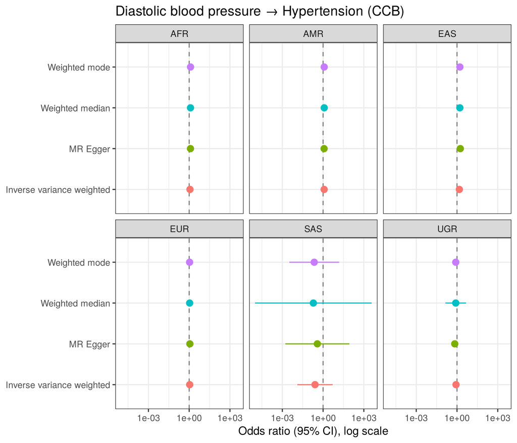

### 5.2.6 Diastolic blood pressure → Hypertension (ACEI)

MR estimates: Diastolic blood pressure → Hypertension (ACEI)

| population | outcome_population | method | nsnp | b | se | pval | OR (95% CI) |
| --- | --- | --- | --- | --- | --- | --- | --- |
| AFR | AFR | Wald ratio | 1 | 0.144 | 0.895 | 8.72e-01 | 1.155 (0.200–6.665) |
| AMR | AMR | Wald ratio | 1 | 0.410 | 0.126 | 1.16e-03 | 1.507 (1.177–1.931) |
| EAS | EAS | Wald ratio | 1 | -0.901 | 0.309 | 3.56e-03 | 0.406 (0.222–0.744) |
| EUR | EUR | Wald ratio | 1 | 0.174 | 0.020 | 1.02e-18 | 1.190 (1.145–1.237) |
| SAS | SAS | Wald ratio | 1 | 1.051 | 23.101 | 9.64e-01 | 2.861 (0.000–131977249012408336384.000) |
| UGR | AFR | Wald ratio | 1 | 0.062 | 0.388 | 8.72e-01 | 1.064 (0.498–2.276) |

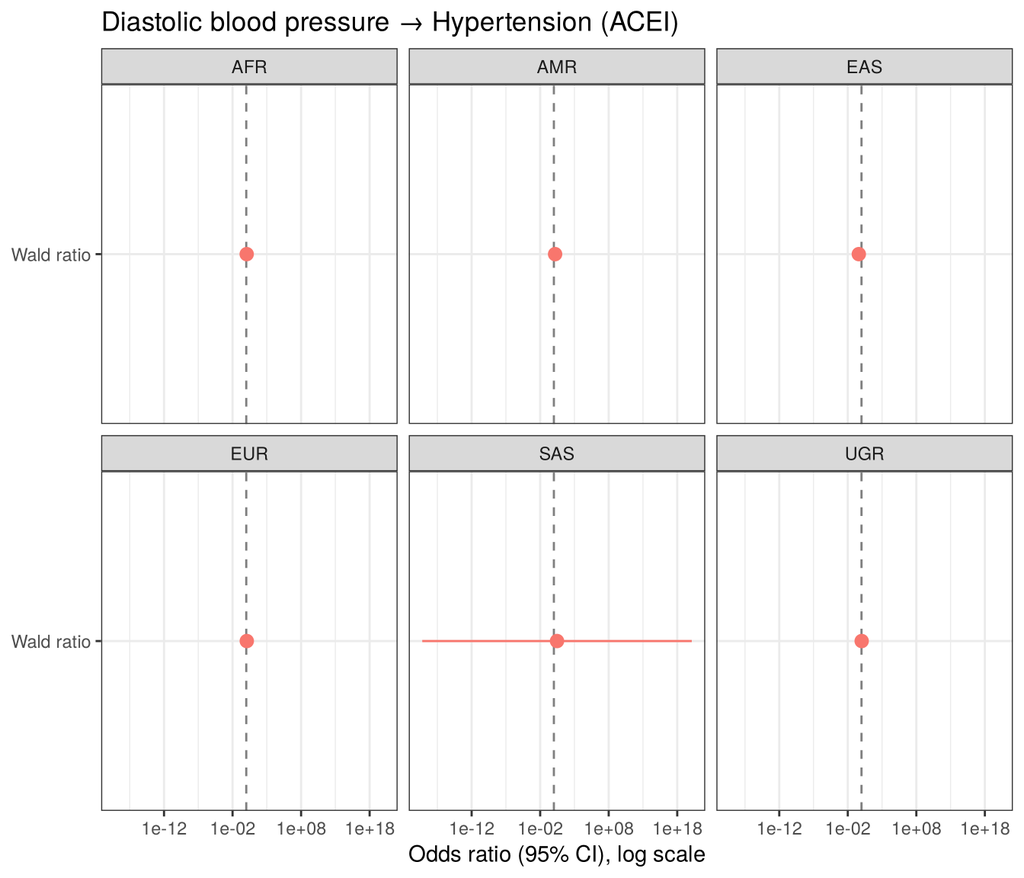

### 5.2.7 Diastolic blood pressure → Stroke (BB)

MR estimates: Diastolic blood pressure → Stroke (BB)

| population | outcome_population | method | nsnp | b | se | pval | OR (95% CI) |
| --- | --- | --- | --- | --- | --- | --- | --- |
| AFR | AFR | Inverse variance weighted | 2 | -1.113 | 2.820 | 6.93e-01 | 0.328 (0.001–82.506) |
| AMR | AMR | Inverse variance weighted | 2 | 0.121 | 0.152 | 4.26e-01 | 1.129 (0.838–1.520) |
| EAS | EAS | Inverse variance weighted | 2 | 0.131 | 0.237 | 5.79e-01 | 1.140 (0.717–1.814) |
| EUR | EUR | Inverse variance weighted | 2 | 0.042 | 0.025 | 9.65e-02 | 1.043 (0.992–1.096) |
| SAS | SAS | Inverse variance weighted | 2 | 0.163 | 0.287 | 5.70e-01 | 1.177 (0.671–2.064) |
| UGR | AFR | Inverse variance weighted | 2 | 1.000 | 1.553 | 5.20e-01 | 2.718 (0.130–56.991) |

Cochran’s Q heterogeneity (between SNPs): Diastolic blood pressure → Stroke (BB)

| population | method | Q | Q_df | Q_pval |
| --- | --- | --- | --- | --- |
| AFR | Inverse variance weighted | 0.33 | 1 | 5.68e-01 |
| AMR | Inverse variance weighted | 1.36 | 1 | 2.44e-01 |
| EAS | Inverse variance weighted | 0.16 | 1 | 6.88e-01 |
| EUR | Inverse variance weighted | 0.43 | 1 | 5.10e-01 |
| SAS | Inverse variance weighted | 0.23 | 1 | 6.34e-01 |
| UGR | Inverse variance weighted | 0.07 | 1 | 7.96e-01 |

MR-Egger intercept test: Diastolic blood pressure → Stroke (BB)

| population | egger_intercept | se | pval |
| --- | --- | --- | --- |
| AFR | NA | NA | NA |
| AMR | NA | NA | NA |
| EAS | NA | NA | NA |
| EUR | NA | NA | NA |
| SAS | NA | NA | NA |
| UGR | NA | NA | NA |

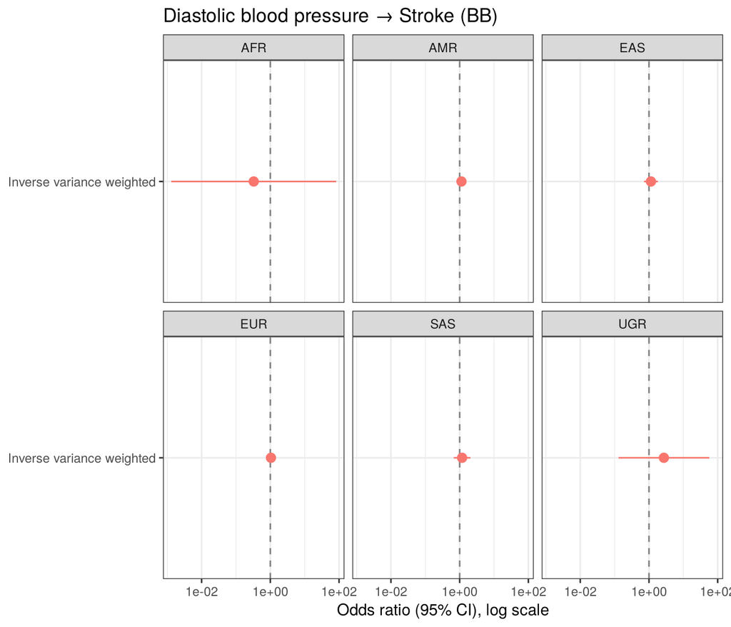

### 5.2.8 Diastolic blood pressure → Stroke (CCB)

MR estimates: Diastolic blood pressure → Stroke (CCB)

| population | outcome_population | method | nsnp | b | se | pval | OR (95% CI) |
| --- | --- | --- | --- | --- | --- | --- | --- |
| AFR | AFR | Inverse variance weighted | 10 | -1.667 | 0.793 | 3.56e-02 | 0.189 (0.040–0.894) |
| AFR | AFR | MR Egger | 10 | -2.075 | 1.149 | 1.08e-01 | 0.126 (0.013–1.193) |
| AFR | AFR | Weighted median | 10 | -1.433 | 1.302 | 2.71e-01 | 0.239 (0.019–3.062) |
| AFR | AFR | Weighted mode | 10 | -1.458 | 0.972 | 1.68e-01 | 0.233 (0.035–1.563) |
| AMR | AMR | Inverse variance weighted | 10 | 0.111 | 0.097 | 2.52e-01 | 1.118 (0.924–1.353) |
| AMR | AMR | MR Egger | 10 | 0.048 | 0.275 | 8.65e-01 | 1.049 (0.612–1.801) |
| AMR | AMR | Weighted median | 10 | 0.040 | 0.123 | 7.43e-01 | 1.041 (0.818–1.326) |
| AMR | AMR | Weighted mode | 10 | 0.018 | 0.148 | 9.09e-01 | 1.018 (0.761–1.361) |
| EAS | EAS | Inverse variance weighted | 10 | 0.529 | 0.186 | 4.45e-03 | 1.697 (1.179–2.442) |
| EAS | EAS | MR Egger | 10 | 0.736 | 0.354 | 7.14e-02 | 2.088 (1.043–4.181) |
| EAS | EAS | Weighted median | 10 | 0.741 | 0.210 | 4.21e-04 | 2.097 (1.390–3.166) |
| EAS | EAS | Weighted mode | 10 | 0.694 | 0.201 | 7.15e-03 | 2.002 (1.351–2.966) |
| EUR | EUR | Inverse variance weighted | 10 | 0.042 | 0.016 | 1.17e-02 | 1.042 (1.009–1.077) |
| EUR | EUR | MR Egger | 10 | 0.078 | 0.038 | 7.32e-02 | 1.081 (1.004–1.165) |
| EUR | EUR | Weighted median | 10 | 0.039 | 0.021 | 6.92e-02 | 1.040 (0.997–1.084) |
| EUR | EUR | Weighted mode | 10 | 0.046 | 0.026 | 1.14e-01 | 1.047 (0.995–1.102) |
| SAS | SAS | Inverse variance weighted | 10 | -0.031 | 0.418 | 9.41e-01 | 0.969 (0.427–2.200) |
| SAS | SAS | MR Egger | 10 | -0.195 | 0.800 | 8.13e-01 | 0.823 (0.171–3.949) |
| SAS | SAS | Weighted median | 10 | -0.485 | 1.016 | 6.33e-01 | 0.616 (0.084–4.510) |
| SAS | SAS | Weighted mode | 10 | -0.305 | 0.526 | 5.76e-01 | 0.737 (0.263–2.067) |
| UGR | AFR | Inverse variance weighted | 10 | -1.099 | 0.736 | 1.36e-01 | 0.333 (0.079–1.411) |
| UGR | AFR | MR Egger | 10 | -1.527 | 1.028 | 1.76e-01 | 0.217 (0.029–1.630) |
| UGR | AFR | Weighted median | 10 | -1.140 | 1.646 | 4.89e-01 | 0.320 (0.013–8.056) |
| UGR | AFR | Weighted mode | 10 | -1.313 | 1.025 | 2.32e-01 | 0.269 (0.036–2.005) |

Cochran’s Q heterogeneity (between SNPs): Diastolic blood pressure → Stroke (CCB)

| population | method | Q | Q_df | Q_pval |
| --- | --- | --- | --- | --- |
| AFR | MR Egger | 3.82 | 8 | 8.73e-01 |
| AFR | Inverse variance weighted | 4.06 | 9 | 9.08e-01 |
| AMR | MR Egger | 12.12 | 8 | 1.46e-01 |
| AMR | Inverse variance weighted | 12.21 | 9 | 2.02e-01 |
| EAS | MR Egger | 12.29 | 8 | 1.39e-01 |
| EAS | Inverse variance weighted | 13.03 | 9 | 1.61e-01 |
| EUR | MR Egger | 6.06 | 8 | 6.40e-01 |
| EUR | Inverse variance weighted | 7.21 | 9 | 6.15e-01 |
| SAS | MR Egger | 12.67 | 8 | 1.24e-01 |
| SAS | Inverse variance weighted | 12.77 | 9 | 1.73e-01 |
| UGR | MR Egger | 5.89 | 8 | 6.59e-01 |
| UGR | Inverse variance weighted | 6.25 | 9 | 7.15e-01 |

MR-Egger intercept test: Diastolic blood pressure → Stroke (CCB)

| population | egger_intercept | se | pval |
| --- | --- | --- | --- |
| AFR | 0.2789 | 0.5683 | 6.37e-01 |
| AMR | 0.0173 | 0.0699 | 8.11e-01 |
| EAS | -0.0493 | 0.0708 | 5.06e-01 |
| EUR | -0.0080 | 0.0075 | 3.14e-01 |
| SAS | 0.0825 | 0.3353 | 8.12e-01 |
| UGR | 0.3269 | 0.5482 | 5.67e-01 |

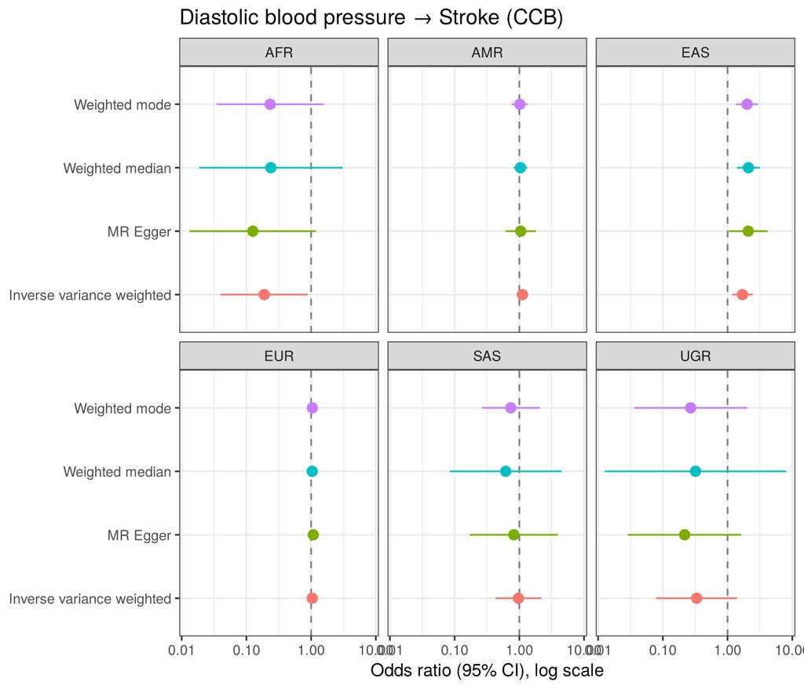

### 5.2.9 Diastolic blood pressure → Stroke (ACEI)

MR estimates: Diastolic blood pressure → Stroke (ACEI)

| population | outcome_population | method | nsnp | b | se | pval | OR (95% CI) |
| --- | --- | --- | --- | --- | --- | --- | --- |
| AFR | AFR | Wald ratio | 1 | -0.672 | 3.871 | 8.62e-01 | 0.511 (0.000–1008.823) |
| AMR | AMR | Wald ratio | 1 | 0.352 | 0.589 | 5.50e-01 | 1.422 (0.448–4.508) |
| EAS | EAS | Wald ratio | 1 | 1.493 | 0.610 | 1.43e-02 | 4.449 (1.347–14.697) |
| EUR | EUR | Wald ratio | 1 | 0.111 | 0.037 | 2.70e-03 | 1.117 (1.039–1.201) |
| SAS | SAS | Wald ratio | 1 | -0.568 | 5.330 | 9.15e-01 | 0.567 (0.000–19509.449) |
| UGR | AFR | Wald ratio | 1 | -0.291 | 1.678 | 8.62e-01 | 0.747 (0.028–20.053) |

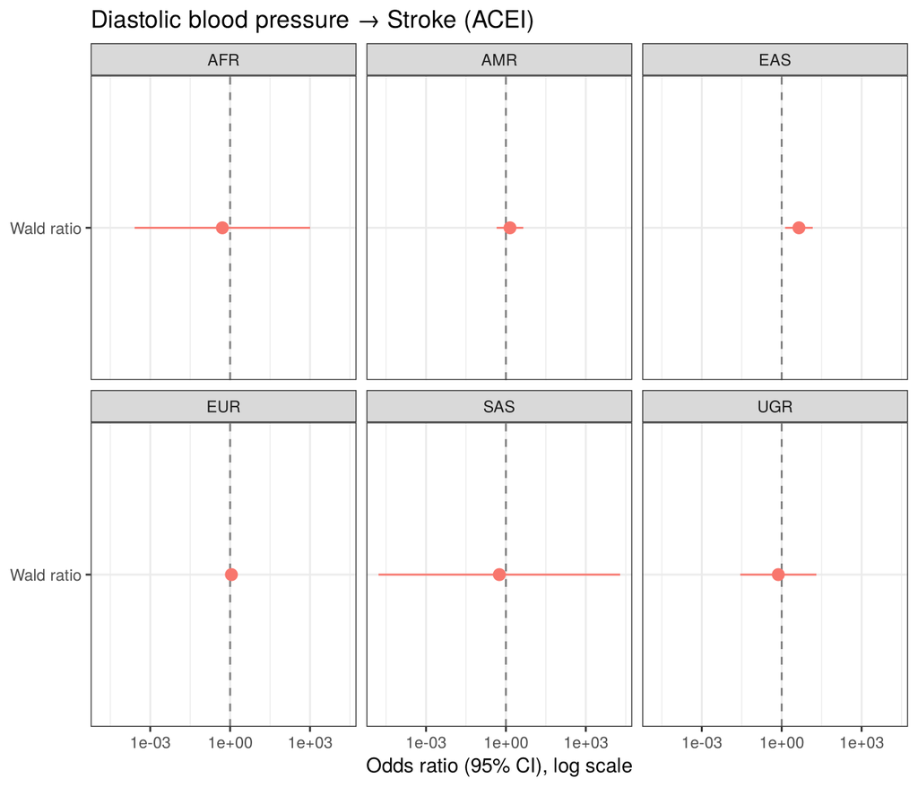

### 5.2.10 LDL cholesterol → Coronary heart disease (Statins)

MR estimates: LDL cholesterol → Coronary heart disease (Statins)

| population | outcome_population | method | nsnp | b | se | pval | OR (95% CI) |
| --- | --- | --- | --- | --- | --- | --- | --- |
| AFR | AFR | Inverse variance weighted | 54 | 1.651 | 2.016 | 4.13e-01 | 5.210 (0.100–270.861) |
| AFR | AFR | MR Egger | 54 | 1.650 | 3.356 | 6.25e-01 | 5.209 (0.007–3747.223) |
| AFR | AFR | Weighted median | 54 | 1.007 | 2.675 | 7.07e-01 | 2.737 (0.014–517.842) |
| AFR | AFR | Weighted mode | 54 | 0.637 | 30.609 | 9.83e-01 | 1.891 (0.000–214734829448093912430280704.000) |
| AMR | AMR | Inverse variance weighted | 53 | -0.042 | 0.044 | 3.39e-01 | 0.959 (0.881–1.045) |
| AMR | AMR | MR Egger | 53 | -0.087 | 0.077 | 2.65e-01 | 0.916 (0.787–1.067) |
| AMR | AMR | Weighted median | 53 | -0.009 | 0.059 | 8.80e-01 | 0.991 (0.883–1.112) |
| AMR | AMR | Weighted mode | 53 | -0.030 | 0.160 | 8.50e-01 | 0.970 (0.709–1.328) |
| EAS | EAS | Inverse variance weighted | 54 | 0.770 | 0.122 | 2.81e-10 | 2.160 (1.701–2.745) |
| EAS | EAS | MR Egger | 54 | 0.844 | 0.227 | 4.80e-04 | 2.326 (1.492–3.626) |
| EAS | EAS | Weighted median | 54 | 0.572 | 0.176 | 1.16e-03 | 1.772 (1.255–2.502) |
| EAS | EAS | Weighted mode | 54 | -0.190 | 432.575 | 1.00e+00 | 0.827 (0.000– Inf) |
| EUR | EUR | Inverse variance weighted | 54 | 0.446 | 0.059 | 3.91e-14 | 1.561 (1.391–1.753) |
| EUR | EUR | MR Egger | 54 | 0.139 | 0.073 | 6.22e-02 | 1.149 (0.996–1.325) |
| EUR | EUR | Weighted median | 54 | 0.176 | 0.076 | 2.11e-02 | 1.192 (1.027–1.384) |
| EUR | EUR | Weighted mode | 54 | 0.232 | 0.071 | 1.88e-03 | 1.262 (1.098–1.450) |
| SAS | SAS | Inverse variance weighted | 54 | -1.186 | 0.323 | 2.38e-04 | 0.305 (0.162–0.575) |
| SAS | SAS | MR Egger | 54 | -1.689 | 0.513 | 1.79e-03 | 0.185 (0.068–0.505) |
| SAS | SAS | Weighted median | 54 | -1.171 | 0.523 | 2.52e-02 | 0.310 (0.111–0.864) |
| SAS | SAS | Weighted mode | 54 | -1.129 | 0.889 | 2.09e-01 | 0.323 (0.057–1.845) |
| UGR | AFR | Inverse variance weighted | 54 | 3.906 | 2.227 | 7.94e-02 | 49.691 (0.632–3905.189) |
| UGR | AFR | MR Egger | 54 | 2.779 | 3.915 | 4.81e-01 | 16.100 (0.007–34653.002) |
| UGR | AFR | Weighted median | 54 | 4.467 | 3.151 | 1.56e-01 | 87.127 (0.181–41886.439) |
| UGR | AFR | Weighted mode | 54 | 3.292 | 7.088 | 6.44e-01 | 26.893 (0.000–29048166.971) |

Cochran’s Q heterogeneity (between SNPs): LDL cholesterol → Coronary heart disease (Statins)

| population | method | Q | Q_df | Q_pval |
| --- | --- | --- | --- | --- |
| AFR | MR Egger | 72.95 | 52 | 2.92e-02 |
| AFR | Inverse variance weighted | 72.95 | 53 | 3.59e-02 |
| AMR | MR Egger | 44.81 | 51 | 7.16e-01 |
| AMR | Inverse variance weighted | 45.32 | 52 | 7.32e-01 |
| EAS | MR Egger | 32.80 | 52 | 9.83e-01 |
| EAS | Inverse variance weighted | 32.95 | 53 | 9.86e-01 |
| EUR | MR Egger | 68.57 | 52 | 6.15e-02 |
| EUR | Inverse variance weighted | 108.82 | 53 | 9.92e-06 |
| SAS | MR Egger | 33.49 | 52 | 9.78e-01 |
| SAS | Inverse variance weighted | 35.09 | 53 | 9.73e-01 |
| UGR | MR Egger | 69.66 | 52 | 5.15e-02 |
| UGR | Inverse variance weighted | 69.82 | 53 | 6.05e-02 |

MR-Egger intercept test: LDL cholesterol → Coronary heart disease (Statins)

| population | egger_intercept | se | pval |
| --- | --- | --- | --- |
| AFR | 0.0000 | 0.2430 | 1.00e+00 |
| AMR | 0.0029 | 0.0041 | 4.80e-01 |
| EAS | -0.0042 | 0.0109 | 7.01e-01 |
| EUR | 0.0118 | 0.0021 | 1.07e-06 |
| SAS | 0.0563 | 0.0446 | 2.13e-01 |
| UGR | 0.0882 | 0.2511 | 7.27e-01 |

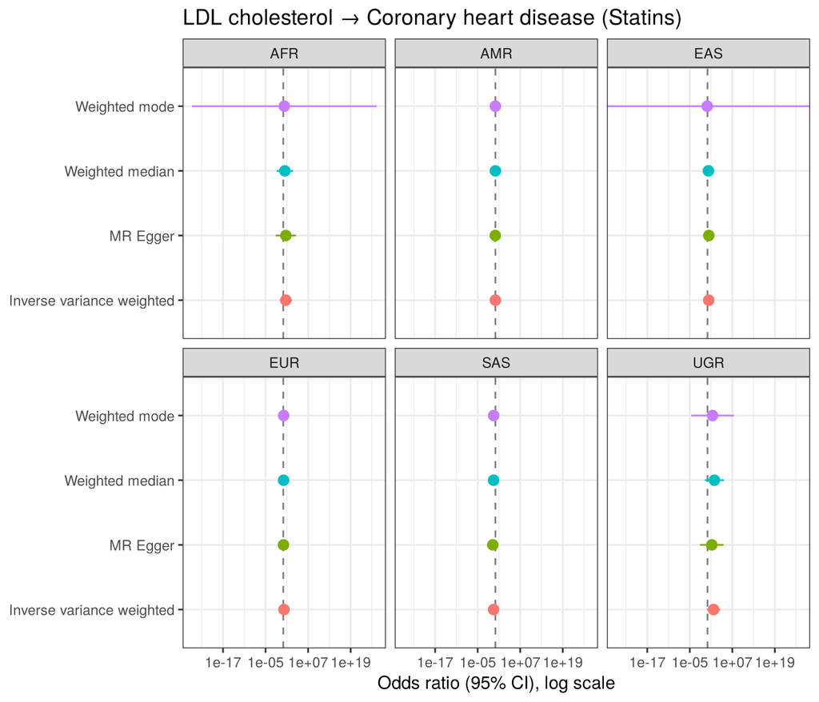

### 5.2.11 LDL cholesterol → Coronary heart disease (Ezetimibe)

MR estimates: LDL cholesterol → Coronary heart disease (Ezetimibe)

| population | outcome_population | method | nsnp | b | se | pval | OR (95% CI) |
| --- | --- | --- | --- | --- | --- | --- | --- |
| AFR | AFR | Inverse variance weighted | 12 | 1.138 | 11.294 | 9.20e-01 | 3.121 (0.000–12831825977.583) |
| AFR | AFR | MR Egger | 12 | 3.341 | 14.199 | 8.19e-01 | 28.254 (0.000–34468485527197.891) |
| AFR | AFR | Weighted median | 12 | -3.583 | 136.115 | 9.79e-01 | 0.028 (0.000–2027839947799851715335625621192349410208030581174764836164954525912000048492416772155629399118258917391528101937152.000) |
| AFR | AFR | Weighted mode | 12 | -2.791 | 16.117 | 8.66e-01 | 0.061 (0.000–3210145638571.945) |
| AMR | AMR | Inverse variance weighted | 12 | -0.066 | 0.182 | 7.17e-01 | 0.936 (0.656–1.337) |
| AMR | AMR | MR Egger | 12 | -1.203 | 0.864 | 1.94e-01 | 0.300 (0.055–1.632) |
| AMR | AMR | Weighted median | 12 | -0.230 | 0.251 | 3.59e-01 | 0.794 (0.486–1.299) |
| AMR | AMR | Weighted mode | 12 | -0.190 | 0.264 | 4.87e-01 | 0.827 (0.493–1.388) |
| EAS | EAS | Inverse variance weighted | 12 | 2.599 | 1.560 | 9.57e-02 | 13.449 (0.632–286.064) |
| EAS | EAS | MR Egger | 12 | -0.770 | 2.632 | 7.76e-01 | 0.463 (0.003–80.513) |
| EAS | EAS | Weighted median | 12 | -1.068 | 77.192 | 9.89e-01 | 0.344 (0.000–175002961735025275145275232980896094771118199336728626744107466752.000) |
| EAS | EAS | Weighted mode | 12 | -1.447 | 2.171 | 5.19e-01 | 0.235 (0.003–16.577) |
| EUR | EUR | Inverse variance weighted | 12 | 0.975 | 0.261 | 1.91e-04 | 2.652 (1.589–4.428) |
| EUR | EUR | MR Egger | 12 | 1.027 | 0.322 | 9.61e-03 | 2.792 (1.487–5.244) |
| EUR | EUR | Weighted median | 12 | 1.043 | 0.270 | 1.15e-04 | 2.838 (1.670–4.822) |
| EUR | EUR | Weighted mode | 12 | 1.026 | 0.275 | 3.34e-03 | 2.791 (1.627–4.788) |
| SAS | SAS | Inverse variance weighted | 12 | -0.854 | 0.833 | 3.05e-01 | 0.426 (0.083–2.178) |
| SAS | SAS | MR Egger | 12 | -0.175 | 1.635 | 9.17e-01 | 0.839 (0.034–20.681) |
| SAS | SAS | Weighted median | 12 | -0.666 | 1.790 | 7.10e-01 | 0.514 (0.015–17.153) |
| SAS | SAS | Weighted mode | 12 | -0.807 | 1.273 | 5.39e-01 | 0.446 (0.037–5.414) |
| UGR | AFR | Inverse variance weighted | 12 | 4.904 | 10.005 | 6.24e-01 | 134.840 (0.000–44305052734.186) |
| UGR | AFR | MR Egger | 12 | -7.894 | 16.899 | 6.50e-01 | 0.000 (0.000–90396702959.900) |
| UGR | AFR | Weighted median | 12 | -0.058 | 21.034 | 9.98e-01 | 0.944 (0.000–757213798974945536.000) |
| UGR | AFR | Weighted mode | 12 | -2.060 | 19.770 | 9.19e-01 | 0.127 (0.000–8589721615812371.000) |

Cochran’s Q heterogeneity (between SNPs): LDL cholesterol → Coronary heart disease (Ezetimibe)

| population | method | Q | Q_df | Q_pval |
| --- | --- | --- | --- | --- |
| AFR | MR Egger | 5.58 | 10 | 8.49e-01 |
| AFR | Inverse variance weighted | 5.65 | 11 | 8.96e-01 |
| AMR | MR Egger | 1.66 | 10 | 9.98e-01 |
| AMR | Inverse variance weighted | 3.47 | 11 | 9.83e-01 |
| EAS | MR Egger | 4.89 | 10 | 8.98e-01 |
| EAS | Inverse variance weighted | 7.42 | 11 | 7.64e-01 |
| EUR | MR Egger | 11.60 | 10 | 3.12e-01 |
| EUR | Inverse variance weighted | 11.71 | 11 | 3.86e-01 |
| SAS | MR Egger | 3.54 | 10 | 9.66e-01 |
| SAS | Inverse variance weighted | 3.77 | 11 | 9.76e-01 |
| UGR | MR Egger | 4.53 | 10 | 9.20e-01 |
| UGR | Inverse variance weighted | 5.42 | 11 | 9.09e-01 |

MR-Egger intercept test: LDL cholesterol → Coronary heart disease (Ezetimibe)

| population | egger_intercept | se | pval |
| --- | --- | --- | --- |
| AFR | -0.0844 | 0.3298 | 8.03e-01 |
| AMR | 0.0274 | 0.0203 | 2.08e-01 |
| EAS | 0.0265 | 0.0167 | 1.43e-01 |
| EUR | -0.0009 | 0.0031 | 7.69e-01 |
| SAS | -0.0469 | 0.0972 | 6.40e-01 |
| UGR | 0.4163 | 0.4430 | 3.69e-01 |

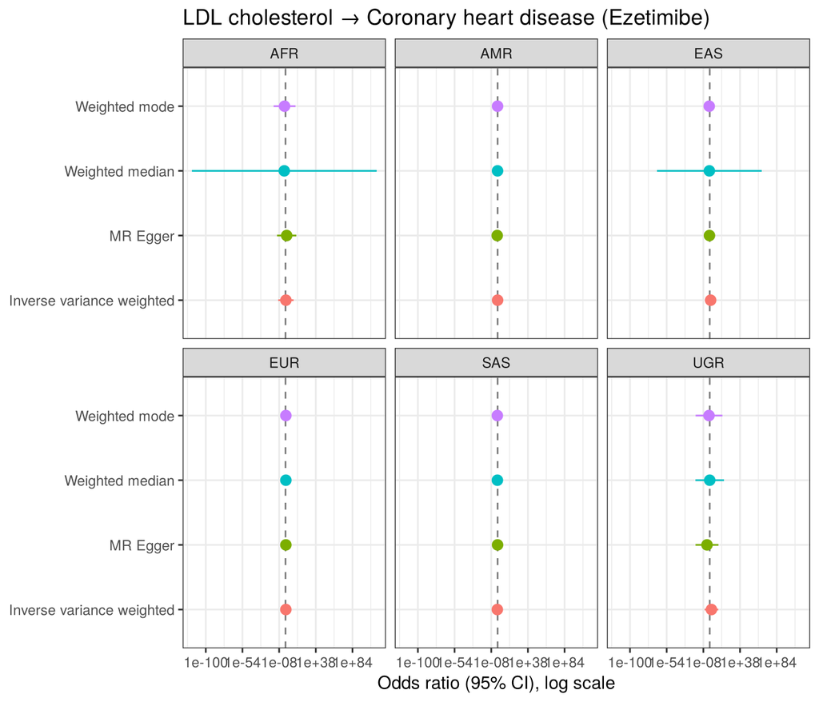

### 5.2.12 LDL cholesterol → Hypertension (Statins)

MR estimates: LDL cholesterol → Hypertension (Statins)

| population | outcome_population | method | nsnp | b | se | pval | OR (95% CI) |
| --- | --- | --- | --- | --- | --- | --- | --- |
| AFR | AFR | Inverse variance weighted | 8 | 1.329 | 1.363 | 3.29e-01 | 3.778 (0.261–54.624) |
| AFR | AFR | MR Egger | 8 | 2.553 | 2.257 | 3.01e-01 | 12.846 (0.154–1071.775) |
| AFR | AFR | Weighted median | 8 | 1.724 | 1.856 | 3.53e-01 | 5.609 (0.148–213.140) |
| AFR | AFR | Weighted mode | 8 | 1.690 | 1.571 | 3.18e-01 | 5.419 (0.249–117.726) |
| AMR | AMR | Inverse variance weighted | 7 | -0.091 | 0.085 | 2.85e-01 | 0.913 (0.772–1.079) |
| AMR | AMR | MR Egger | 7 | -0.077 | 0.165 | 6.62e-01 | 0.926 (0.670–1.280) |
| AMR | AMR | Weighted median | 7 | -0.108 | 0.101 | 2.87e-01 | 0.898 (0.737–1.095) |
| AMR | AMR | Weighted mode | 7 | -0.083 | 0.093 | 4.08e-01 | 0.920 (0.767–1.105) |
| EAS | EAS | Inverse variance weighted | 7 | -0.278 | 0.427 | 5.16e-01 | 0.757 (0.328–1.750) |
| EAS | EAS | MR Egger | 7 | -0.423 | 0.924 | 6.67e-01 | 0.655 (0.107–4.009) |
| EAS | EAS | Weighted median | 7 | -0.631 | 0.484 | 1.93e-01 | 0.532 (0.206–1.374) |
| EAS | EAS | Weighted mode | 7 | -0.748 | 0.541 | 2.15e-01 | 0.473 (0.164–1.365) |
| EUR | EUR | Inverse variance weighted | 8 | 0.049 | 0.050 | 3.30e-01 | 1.050 (0.951–1.159) |
| EUR | EUR | MR Egger | 8 | 0.086 | 0.096 | 4.04e-01 | 1.090 (0.903–1.315) |
| EUR | EUR | Weighted median | 8 | 0.053 | 0.052 | 3.07e-01 | 1.055 (0.952–1.168) |
| EUR | EUR | Weighted mode | 8 | 0.035 | 0.051 | 5.11e-01 | 1.036 (0.937–1.145) |
| SAS | SAS | Inverse variance weighted | 8 | -18.476 | 7.142 | 9.68e-03 | 0.000 (0.000–0.011) |
| SAS | SAS | MR Egger | 8 | -35.713 | 12.797 | 3.15e-02 | 0.000 (0.000–0.000) |
| SAS | SAS | Weighted median | 8 | -20.757 | 19.641 | 2.91e-01 | 0.000 (0.000–50621059.893) |
| SAS | SAS | Weighted mode | 8 | -20.421 | 9.807 | 7.58e-02 | 0.000 (0.000–0.302) |
| UGR | AFR | Inverse variance weighted | 8 | -1.905 | 1.579 | 2.28e-01 | 0.149 (0.007–3.288) |
| UGR | AFR | MR Egger | 8 | -3.624 | 3.688 | 3.64e-01 | 0.027 (0.000–36.786) |
| UGR | AFR | Weighted median | 8 | -2.189 | 2.464 | 3.74e-01 | 0.112 (0.001–14.022) |
| UGR | AFR | Weighted mode | 8 | -2.244 | 2.176 | 3.37e-01 | 0.106 (0.001–7.545) |

Cochran’s Q heterogeneity (between SNPs): LDL cholesterol → Hypertension (Statins)

| population | method | Q | Q_df | Q_pval |
| --- | --- | --- | --- | --- |
| AFR | MR Egger | 4.62 | 6 | 5.94e-01 |
| AFR | Inverse variance weighted | 5.08 | 7 | 6.50e-01 |
| AMR | MR Egger | 2.96 | 5 | 7.06e-01 |
| AMR | Inverse variance weighted | 2.97 | 6 | 8.12e-01 |
| EAS | MR Egger | 7.95 | 5 | 1.59e-01 |
| EAS | Inverse variance weighted | 8.00 | 6 | 2.38e-01 |
| EUR | MR Egger | 8.40 | 6 | 2.10e-01 |
| EUR | Inverse variance weighted | 8.71 | 7 | 2.74e-01 |
| SAS | MR Egger | 5.41 | 6 | 4.93e-01 |
| SAS | Inverse variance weighted | 7.91 | 7 | 3.40e-01 |
| UGR | MR Egger | 4.31 | 6 | 6.35e-01 |
| UGR | Inverse variance weighted | 4.58 | 7 | 7.11e-01 |

MR-Egger intercept test: LDL cholesterol → Hypertension (Statins)

| population | egger_intercept | se | pval |
| --- | --- | --- | --- |
| AFR | -0.1117 | 0.1642 | 5.22e-01 |
| AMR | -0.0011 | 0.0107 | 9.21e-01 |
| EAS | 0.0085 | 0.0471 | 8.63e-01 |
| EUR | -0.0018 | 0.0038 | 6.58e-01 |
| SAS | 2.0640 | 1.3042 | 1.65e-01 |
| UGR | 0.1195 | 0.2317 | 6.24e-01 |

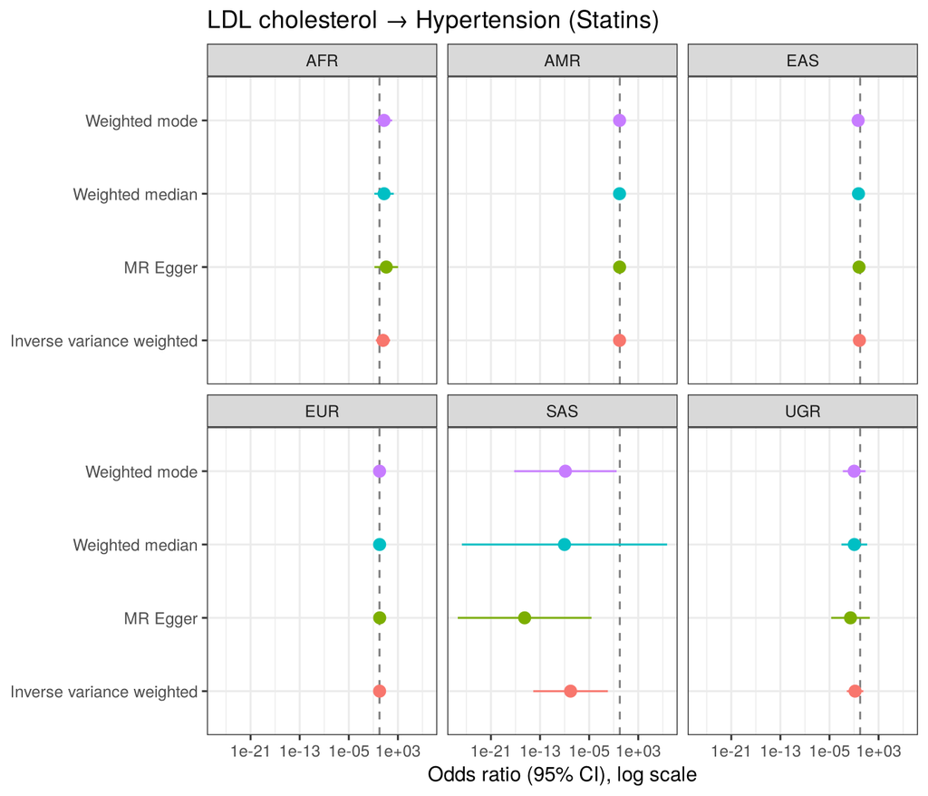

### 5.2.13 LDL cholesterol → Hypertension (Ezetimibe)

MR estimates: LDL cholesterol → Hypertension (Ezetimibe)

| population | outcome_population | method | nsnp | b | se | pval | OR (95% CI) |
| --- | --- | --- | --- | --- | --- | --- | --- |
| AFR | AFR | Inverse variance weighted | 2 | 5.578 | 5.693 | 3.27e-01 | 264.656 (0.004–18577334.842) |
| AMR | AMR | Inverse variance weighted | 2 | 0.456 | 0.389 | 2.42e-01 | 1.577 (0.735–3.384) |
| EAS | EAS | Inverse variance weighted | 2 | 7.885 | 20.172 | 6.96e-01 | 2658.142 (0.000–394023527848816082944.000) |
| EUR | EUR | Inverse variance weighted | 2 | 0.456 | 0.262 | 8.25e-02 | 1.577 (0.943–2.637) |
| SAS | SAS | Inverse variance weighted | 2 | 1.266 | 28.666 | 9.65e-01 | 3.547 (0.000–8925202228895370660806656.000) |
| UGR | AFR | Inverse variance weighted | 2 | -3.300 | 5.015 | 5.11e-01 | 0.037 (0.000–684.782) |

Cochran’s Q heterogeneity (between SNPs): LDL cholesterol → Hypertension (Ezetimibe)

| population | method | Q | Q_df | Q_pval |
| --- | --- | --- | --- | --- |
| AFR | Inverse variance weighted | 0.09 | 1 | 7.65e-01 |
| AMR | Inverse variance weighted | 0.00 | 1 | 9.52e-01 |
| EAS | Inverse variance weighted | 2.23 | 1 | 1.36e-01 |
| EUR | Inverse variance weighted | 1.89 | 1 | 1.69e-01 |
| SAS | Inverse variance weighted | 0.04 | 1 | 8.33e-01 |
| UGR | Inverse variance weighted | 0.62 | 1 | 4.33e-01 |

MR-Egger intercept test: LDL cholesterol → Hypertension (Ezetimibe)

| population | egger_intercept | se | pval |
| --- | --- | --- | --- |
| AFR | NA | NA | NA |
| AMR | NA | NA | NA |
| EAS | NA | NA | NA |
| EUR | NA | NA | NA |
| SAS | NA | NA | NA |
| UGR | NA | NA | NA |

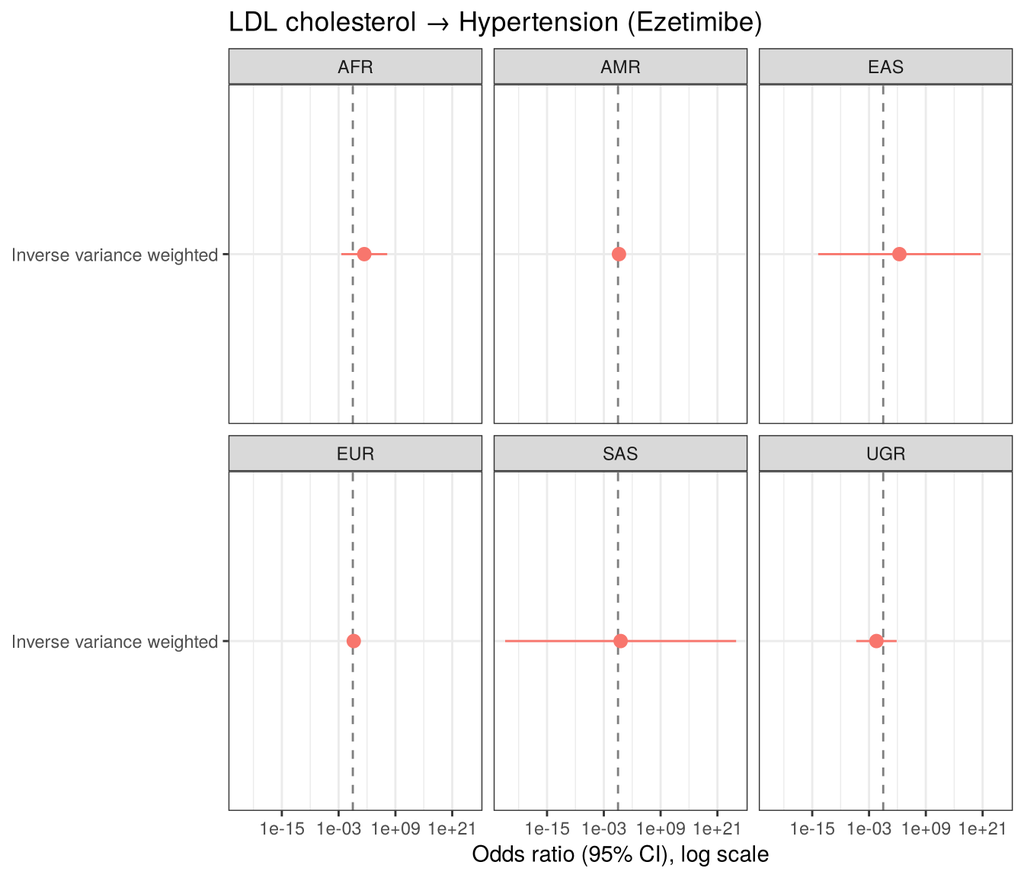

### 5.2.14 LDL cholesterol → Stroke (Statins)

MR estimates: LDL cholesterol → Stroke (Statins)

| population | outcome_population | method | nsnp | b | se | pval | OR (95% CI) |
| --- | --- | --- | --- | --- | --- | --- | --- |
| AFR | AFR | Inverse variance weighted | 8 | 0.733 | 5.916 | 9.01e-01 | 2.082 (0.000–226303.704) |
| AFR | AFR | MR Egger | 8 | -9.030 | 9.758 | 3.90e-01 | 0.000 (0.000–24238.927) |
| AFR | AFR | Weighted median | 8 | -0.559 | 7.729 | 9.42e-01 | 0.572 (0.000–2169553.436) |
| AFR | AFR | Weighted mode | 8 | -0.806 | 6.222 | 9.01e-01 | 0.447 (0.000–88341.434) |
| AMR | AMR | Inverse variance weighted | 7 | -0.516 | 0.452 | 2.53e-01 | 0.597 (0.246–1.447) |
| AMR | AMR | MR Egger | 7 | -0.061 | 0.927 | 9.50e-01 | 0.941 (0.153–5.796) |
| AMR | AMR | Weighted median | 7 | 0.143 | 0.525 | 7.85e-01 | 1.154 (0.412–3.228) |
| AMR | AMR | Weighted mode | 7 | -0.334 | 0.476 | 5.09e-01 | 0.716 (0.282–1.820) |
| EAS | EAS | Inverse variance weighted | 7 | 1.140 | 0.717 | 1.12e-01 | 3.126 (0.767–12.746) |
| EAS | EAS | MR Egger | 7 | 1.434 | 1.427 | 3.61e-01 | 4.195 (0.256–68.729) |
| EAS | EAS | Weighted median | 7 | 0.809 | 0.879 | 3.58e-01 | 2.245 (0.401–12.579) |
| EAS | EAS | Weighted mode | 7 | 0.752 | 0.868 | 4.19e-01 | 2.122 (0.387–11.629) |
| EUR | EUR | Inverse variance weighted | 8 | 0.480 | 0.141 | 6.65e-04 | 1.617 (1.226–2.132) |
| EUR | EUR | MR Egger | 8 | 0.193 | 0.234 | 4.41e-01 | 1.213 (0.767–1.918) |
| EUR | EUR | Weighted median | 8 | 0.264 | 0.113 | 1.94e-02 | 1.302 (1.043–1.625) |
| EUR | EUR | Weighted mode | 8 | 0.425 | 0.096 | 3.07e-03 | 1.530 (1.267–1.847) |
| SAS | SAS | Inverse variance weighted | 8 | -3.301 | 1.550 | 3.32e-02 | 0.037 (0.002–0.769) |
| SAS | SAS | MR Egger | 8 | -3.741 | 2.956 | 2.53e-01 | 0.024 (0.000–7.782) |
| SAS | SAS | Weighted median | 8 | -4.019 | 3.067 | 1.90e-01 | 0.018 (0.000–7.337) |
| SAS | SAS | Weighted mode | 8 | -3.815 | 2.054 | 1.06e-01 | 0.022 (0.000–1.233) |
| UGR | AFR | Inverse variance weighted | 8 | -2.988 | 6.799 | 6.60e-01 | 0.050 (0.000–30894.446) |
| UGR | AFR | MR Egger | 8 | 17.478 | 15.923 | 3.14e-01 | 38964784.868 (0.000–1394900614169800212480.000) |
| UGR | AFR | Weighted median | 8 | 0.092 | 10.521 | 9.93e-01 | 1.096 (0.000–989511738.211) |
| UGR | AFR | Weighted mode | 8 | 1.915 | 8.812 | 8.34e-01 | 6.788 (0.000–214998404.898) |

Cochran’s Q heterogeneity (between SNPs): LDL cholesterol → Stroke (Statins)

| population | method | Q | Q_df | Q_pval |
| --- | --- | --- | --- | --- |
| AFR | MR Egger | 5.44 | 6 | 4.89e-01 |
| AFR | Inverse variance weighted | 7.02 | 7 | 4.27e-01 |
| AMR | MR Egger | 6.92 | 5 | 2.27e-01 |
| AMR | Inverse variance weighted | 7.37 | 6 | 2.88e-01 |
| EAS | MR Egger | 1.40 | 5 | 9.25e-01 |
| EAS | Inverse variance weighted | 1.45 | 6 | 9.62e-01 |
| EUR | MR Egger | 14.20 | 6 | 2.75e-02 |
| EUR | Inverse variance weighted | 19.40 | 7 | 7.02e-03 |
| SAS | MR Egger | 5.42 | 6 | 4.91e-01 |
| SAS | Inverse variance weighted | 5.45 | 7 | 6.05e-01 |
| UGR | MR Egger | 4.82 | 6 | 5.67e-01 |
| UGR | Inverse variance weighted | 6.84 | 7 | 4.46e-01 |

MR-Egger intercept test: LDL cholesterol → Stroke (Statins)

| population | egger_intercept | se | pval |
| --- | --- | --- | --- |
| AFR | 0.8890 | 0.7071 | 2.55e-01 |
| AMR | -0.0346 | 0.0603 | 5.91e-01 |
| EAS | -0.0174 | 0.0728 | 8.21e-01 |
| EUR | 0.0137 | 0.0092 | 1.89e-01 |
| SAS | 0.0527 | 0.3017 | 8.67e-01 |
| UGR | -1.4253 | 1.0027 | 2.05e-01 |

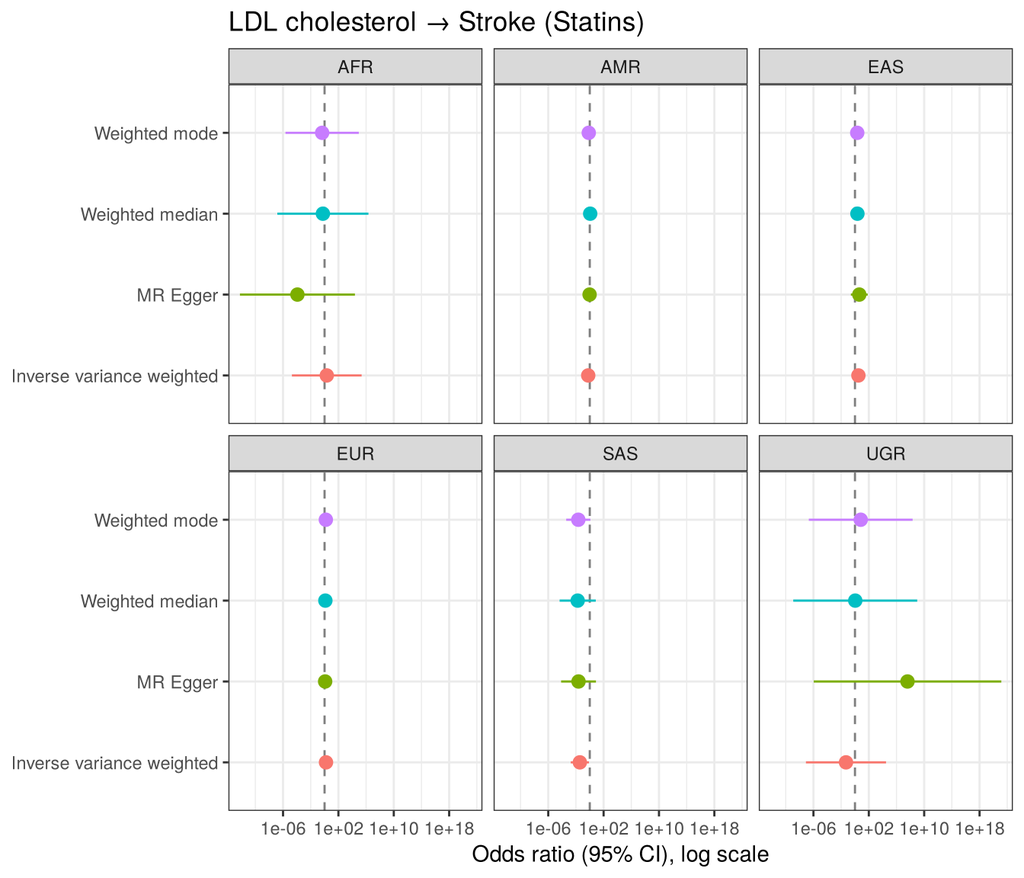